# Manuscript submission code

### Capsule Length

Capsule length is in the same dataset as number of embryos. Check the distribution of the raw data

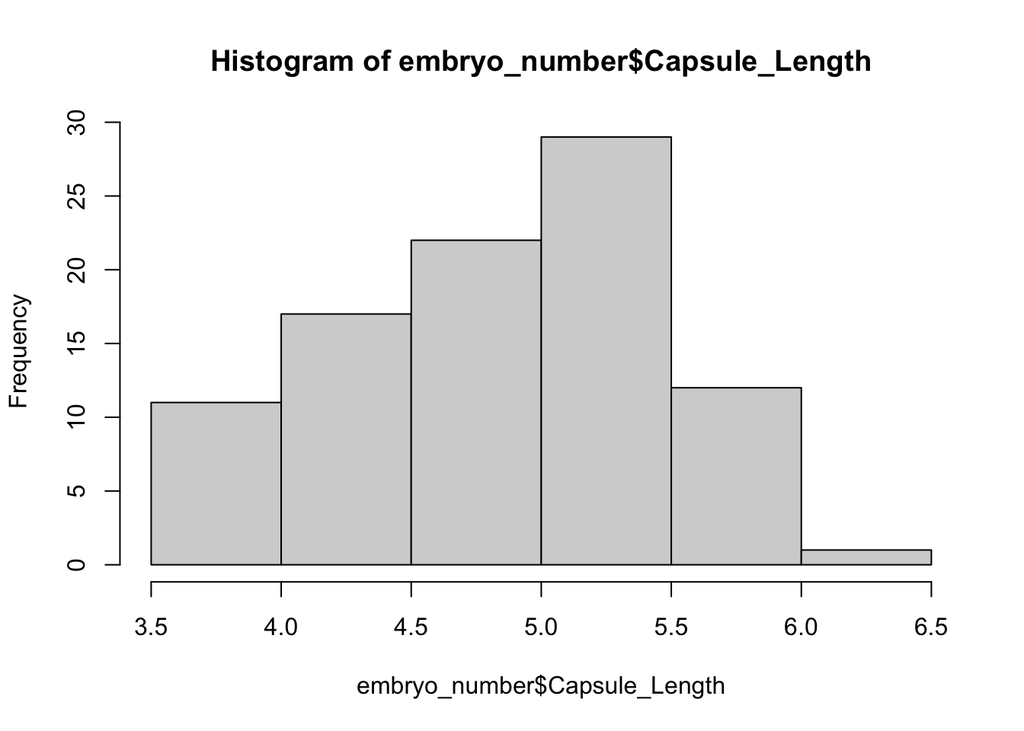

```r
hist(embryo_number$Capsule_Length)
```

Run a GLMM model with a Gamma distribution and log link function. Calculate AIC values.

```r
capsule_gm <-
  glm(Capsule_Length ~ Population + (1 | Aggregation_ID), family = Gamma(link = log), data = embryo_number)

summary(capsule_gm)
```

```
##
## Call:
## glm(formula = Capsule_Length ~ Population + (1 | Aggregation_ID),
##     family = Gamma(link = log), data = embryo_number)
##
## Coefficients: (1 not defined because of singularities)
##                        Estimate Std. Error t value Pr(>|t|)
## (Intercept)             1.39380    0.02500  55.746  < 2e-16 ***
## PopulationCM            0.29136    0.03154   9.239 1.46e-14 ***
## PopulationDB            0.24001    0.03062   7.838 1.06e-11 ***
## PopulationMB            0.10813    0.03154   3.429 0.000929 ***
## PopulationRP            0.12393    0.03909   3.170 0.002103 **
## 1 | Aggregation_IDTRUE       NA         NA      NA       NA
## ---
## Signif. codes:  0 '***' 0.001 '**' 0.01 '*' 0.05 '.' 0.1 ' ' 1
##
## (Dispersion parameter for Gamma family taken to be 0.008126857)
##
##     Null deviance: 1.62417  on 91  degrees of freedom
## Residual deviance: 0.70967  on 87  degrees of freedom
## AIC: 113.69
##
## Number of Fisher Scoring iterations: 4
```

```r
anova(capsule_gm)
```

```
## Analysis of Deviance Table
##
## Model: Gamma, link: log
##
## Response: Capsule_Length
##
## Terms added sequentially (first to last)
##
##
##                    Df Deviance Resid. Df Resid. Dev      F    Pr(>F)
## NULL                                  91    1.62417
## Population          4   0.9145        87    0.70967 28.132 5.322e-15 ***
## 1 | Aggregation_ID  0   0.0000        87    0.70967
## ---
## Signif. codes:  0 '***' 0.001 '**' 0.01 '*' 0.05 '.' 0.1 ' ' 1
```

```r
Anova(capsule_gm)
```

```
## Analysis of Deviance Table (Type II tests)
##
## Response: Capsule_Length
##                    LR Chisq Df Pr(>Chisq)
## Population           112.53  4  < 2.2e-16 ***
## 1 | Aggregation_ID           0
## ---
## Signif. codes:  0 '***' 0.001 '**' 0.01 '*' 0.05 '.' 0.1 ' ' 1
```

```r
AICc(capsule_gm)
```

```
## [1] 114.6741
```

```r
AIC(capsule_gm)
```

```
## [1] 113.6859
```

Calculate pairwise comparisons using emmeans and Tukey adjustments

```r
em <- emmeans(capsule_gm, "Population", data = embryo_number)
contrast(em, "pairwise", adjust = "Tukey")
```

```
##  contrast estimate     SE df t.ratio p.value
##  CB - CM   -0.2914 0.0315 87  -9.239  <.0001
##  CB - DB   -0.2400 0.0306 87  -7.838  <.0001
##  CB - MB   -0.1081 0.0315 87  -3.429  0.0081
##  CB - RP   -0.1239 0.0391 87  -3.170  0.0175
##  CM - DB    0.0513 0.0261 87   1.966  0.2912
##  CM - MB    0.1832 0.0272 87   6.741  <.0001
##  CM - RP    0.1674 0.0357 87   4.694  0.0001
##  DB - MB    0.1319 0.0261 87   5.050  <.0001
##  DB - RP    0.1161 0.0349 87   3.329  0.0109
##  MB - RP   -0.0158 0.0357 87  -0.443  0.9919
##
## Results are given on the log (not the response) scale.
## P value adjustment: tukey method for comparing a family of 5 estimates
```

Plot model residuals to assess model fit

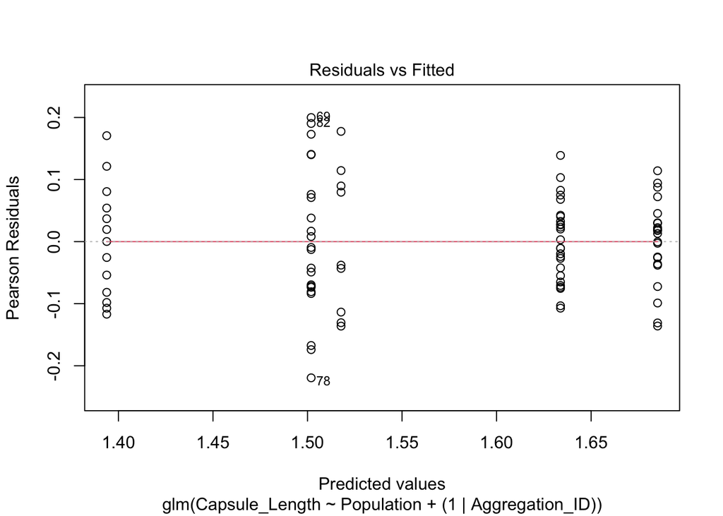

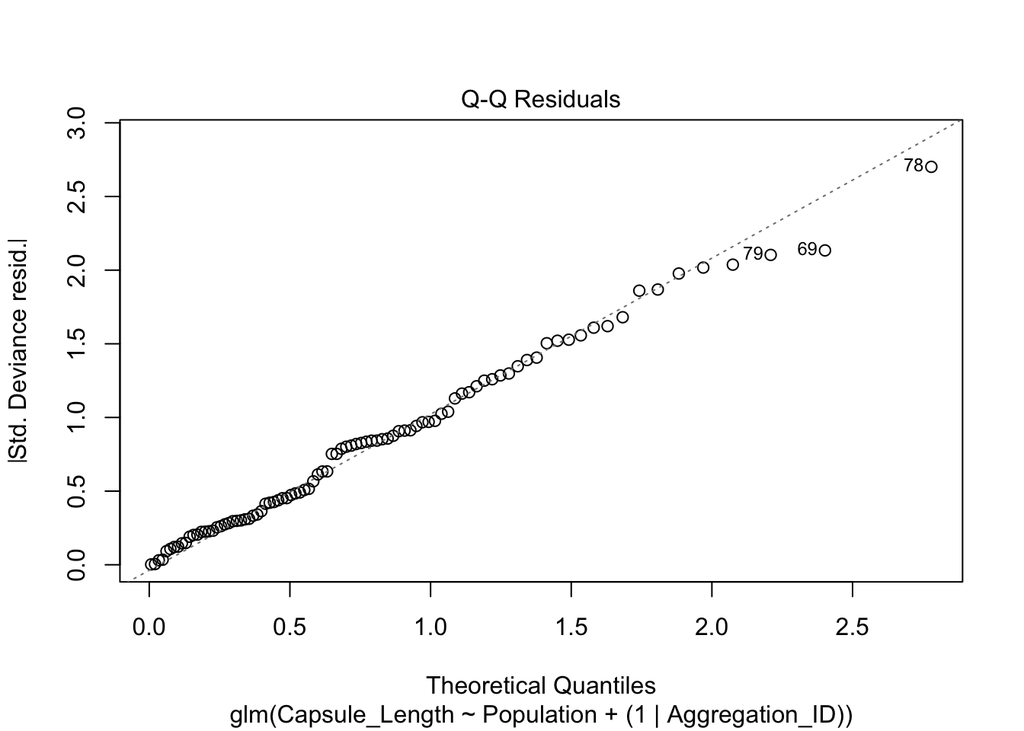

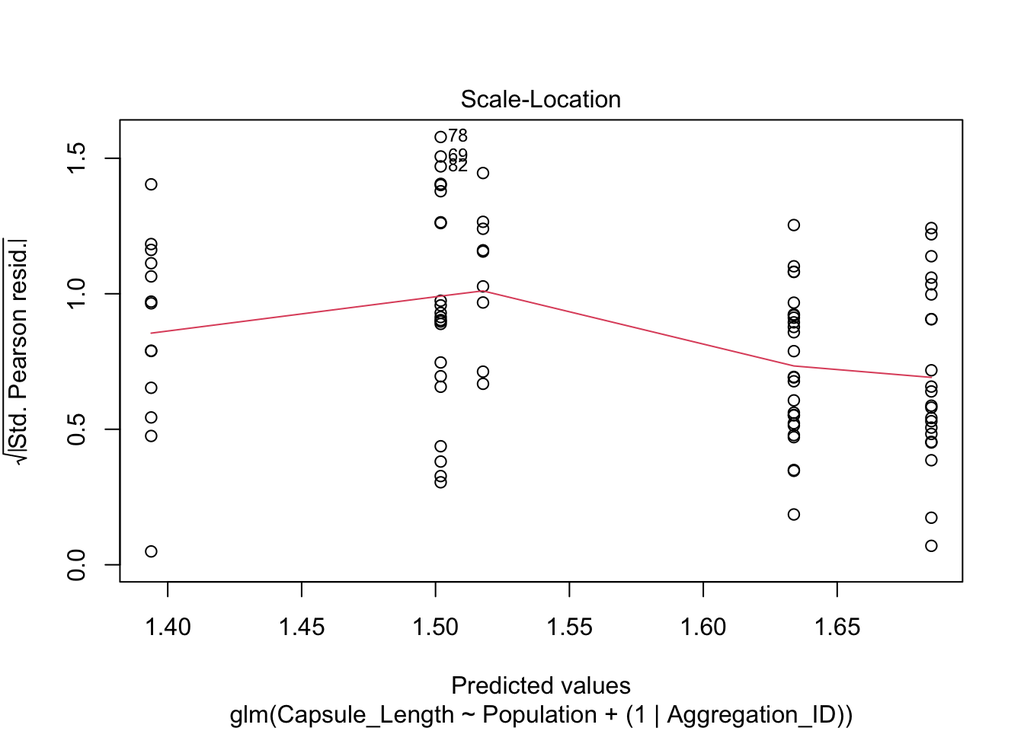

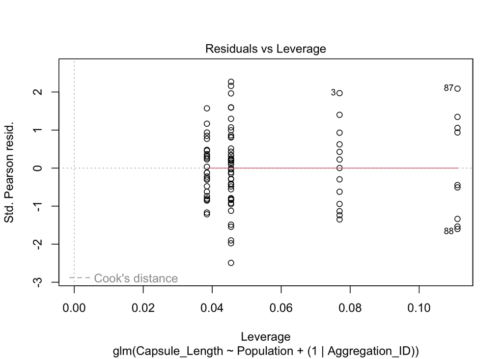

```r
plot(capsule_gm)
```

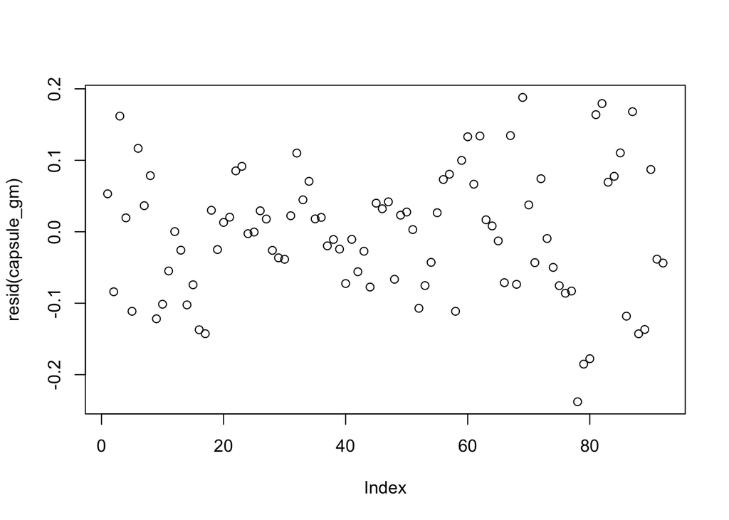

```r
plot(resid(capsule_gm))
```

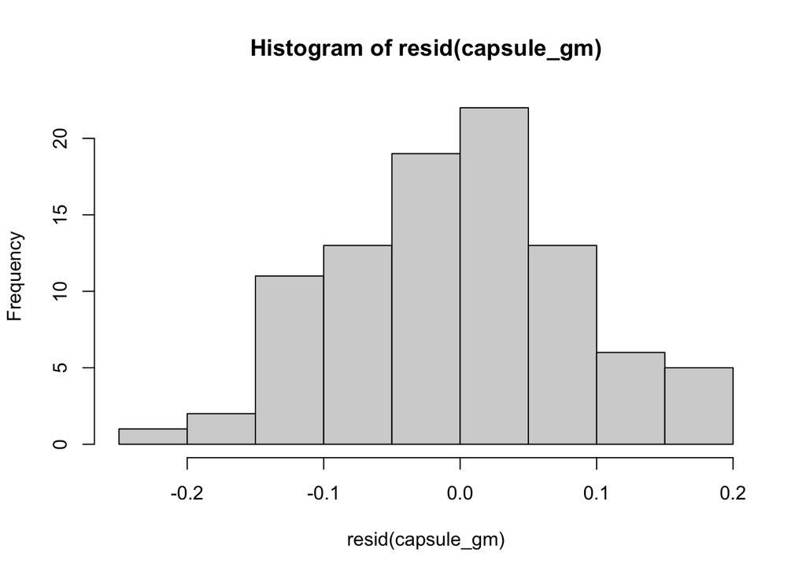

```r
hist(resid(capsule_gm))
```

Q-Q plot of model residuals

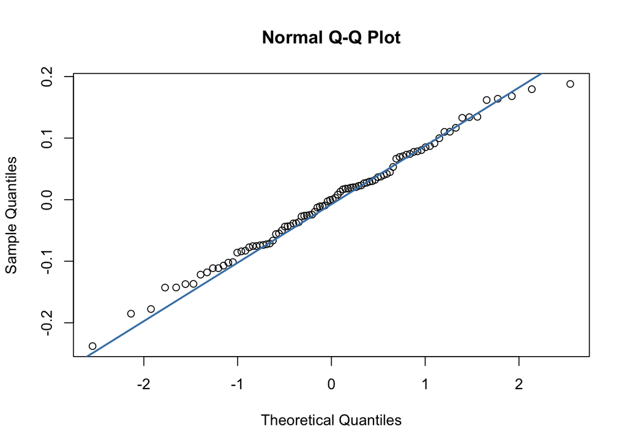

```r
qqnorm(resid(capsule_gm))
qqline(resid(capsule_gm), col = "steelblue", lwd = 2)
```

Back-transform the model estimates to plot on top of the raw data scatter

```r
emmeans(capsule_gm, "Population", type  = "response", data = embryo_number)
```

```
##  Population response     SE df lower.CL upper.CL
##  CB             4.03 0.1008 87     3.83     4.24
##  CM             5.39 0.1037 87     5.19     5.60
##  DB             5.12 0.0906 87     4.95     5.31
##  MB             4.49 0.0863 87     4.32     4.67
##  RP             4.56 0.1371 87     4.30     4.84
##
## Confidence level used: 0.95
## Intervals are back-transformed from the log scale
```

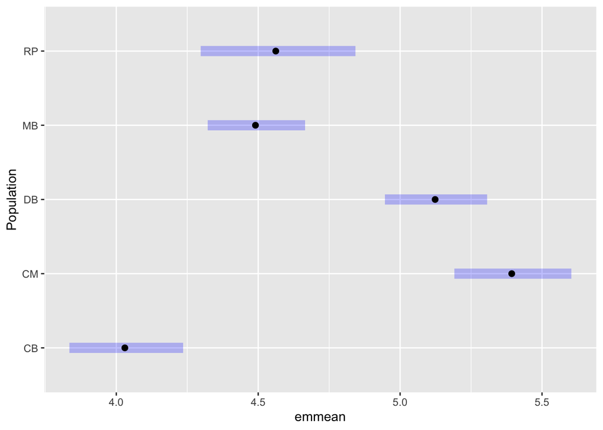

```r
estimates <- emmeans(capsule_gm, "Population", type  = "response", data = embryo_number)

plot(estimates)
```

```r
estimates
```

```
##  Population response     SE df lower.CL upper.CL
##  CB             4.03 0.1008 87     3.83     4.24
##  CM             5.39 0.1037 87     5.19     5.60
##  DB             5.12 0.0906 87     4.95     5.31
##  MB             4.49 0.0863 87     4.32     4.67
##  RP             4.56 0.1371 87     4.30     4.84
##
## Confidence level used: 0.95
## Intervals are back-transformed from the log scale
```

Create data frame of the back-transformed estimates

```r
site <- c("CB", "CM", "DB", "MB", "RP")

est <- c(4.03, 5.39, 5.12, 4.49, 4.56)


err_high <- c(4.24, 5.60, 5.31, 4.67, 4.84)


err_low <- c(3.83, 5.19, 4.95, 4.32, 4.30)


cap_len <- data.frame(Population = site, Estimate = est, Error_high = err_high, Error_low = err_low)

cap_len
```

```
##   Population Estimate Error_high Error_low
## 1         CB     4.03       4.24      3.83
## 2         CM     5.39       5.60      5.19
## 3         DB     5.12       5.31      4.95
## 4         MB     4.49       4.67      4.32
## 5         RP     4.56       4.84      4.30
```

Plot capsule length across populations

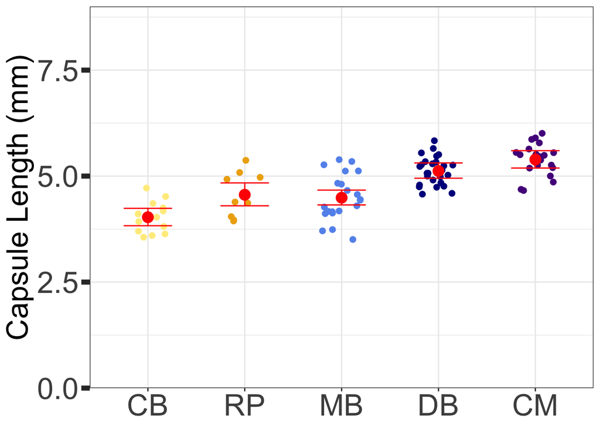

```r
ggplot(embryo_number, aes(x = Population, y = Capsule_Length, color = Population)) +
  geom_jitter(aes(x = Population, y = Capsule_Length), position=position_jitter(w=0.2), size = 2) +
  scale_color_manual(values = c("lightgoldenrod1", "darkgoldenrod2", "cornflowerblue","darkblue", "purple4")) +
  geom_point(data = cap_len, aes(x = Population, y = Estimate), size = 4,  color = "red") +
  geom_errorbar(data = cap_len, aes(x = Population, y = Estimate, ymin = Error_low, ymax = Error_high), color = "red", width = 0.5) +
  theme_bw() +
  theme(legend.position = "none",
        axis.title.x = element_blank(),
        axis.title.y = element_text(size=25),
        axis.text = element_text(size=25),
        axis.ticks.y = element_line(linewidth = 2),
        axis.ticks.length.y = unit(0.25, "cm")) +
  scale_y_continuous(name = "Capsule Length (mm)", expand = c(0,0), limits = c(0,9)) -> cap_len_plot

cap_len_plot$data$Population <- factor(cap_len_plot$data$Population, levels=neworder)

cap_len_plot
```

### Nurse Eggs

Import data

```r
nurse_eggs <- read.csv("/Users/keiramonuki/Documents/Sanford\ Lab/snail_tank_experiment/field_data/nurse_eggs.csv")

head(nurse_eggs)
```

```
##   Population Aggregation Average_hatchling_number        X Nurse_egg
## 1         CB           1                 28.00000 27.00000 -1.000000
## 2         CB           2                 27.33333 31.50000  4.166667
## 3         CB           3                 35.00000 27.50000 -7.500000
## 4         CB           4                 38.50000 50.33333 11.833333
## 5         CB           8                 29.50000 29.20000 -0.300000
## 6         RP           4                 34.66667 38.00000  3.333333
```

Run linear model of nurse egg ratios and calculate AIC

```r
nurse_eggs$Population <- as.factor(nurse_eggs$Population)

nurse_lm <- lm(Nurse_egg ~ Population, data = nurse_eggs)

summary(nurse_lm)
```

```
##
## Call:
## lm(formula = Nurse_egg ~ Population, data = nurse_eggs)
##
## Residuals:
##      Min       1Q   Median       3Q      Max
## -13.9190  -3.8000   0.1071   4.6560  10.3933
##
## Coefficients:
##              Estimate Std. Error t value Pr(>|t|)
## (Intercept)     1.440      3.392   0.424 0.676531
## PopulationCM   15.393      6.346   2.426 0.026709 *
## PopulationDB   22.479      4.442   5.061 9.65e-05 ***
## PopulationMB   20.760      4.797   4.327 0.000457 ***
## PopulationRP    5.966      5.540   1.077 0.296574
## ---
## Signif. codes:  0 '***' 0.001 '**' 0.01 '*' 0.05 '.' 0.1 ' ' 1
##
## Residual standard error: 7.585 on 17 degrees of freedom
## Multiple R-squared:  0.6612, Adjusted R-squared:  0.5815
## F-statistic: 8.295 on 4 and 17 DF,  p-value: 0.0006686
```

```r
anova(nurse_lm)
```

```
## Analysis of Variance Table
##
## Response: Nurse_egg
##            Df  Sum Sq Mean Sq F value    Pr(>F)
## Population  4 1909.13  477.28   8.295 0.0006686 ***
## Residuals  17  978.15   57.54
## ---
## Signif. codes:  0 '***' 0.001 '**' 0.01 '*' 0.05 '.' 0.1 ' ' 1
```

```r
Anova(nurse_lm)
```

```
## Anova Table (Type II tests)
##
## Response: Nurse_egg
##             Sum Sq Df F value    Pr(>F)
## Population 1909.13  4   8.295 0.0006686 ***
## Residuals   978.15 17
## ---
## Signif. codes:  0 '***' 0.001 '**' 0.01 '*' 0.05 '.' 0.1 ' ' 1
```

```r
AICc(nurse_lm)
```

```
## [1] 163.515
```

```r
AIC(nurse_lm)
```

```
## [1] 157.915
```

Calculate pairwise comparisons using emmeans and Tukey adjustments

```r
em <- emmeans(nurse_lm, "Population", data = nurse_eggs)
contrast(em, "pairwise", adjust = "Tukey")
```

```
##  contrast estimate   SE df t.ratio p.value
##  CB - CM    -15.39 6.35 17  -2.426  0.1559
##  CB - DB    -22.48 4.44 17  -5.061  0.0008
##  CB - MB    -20.76 4.80 17  -4.327  0.0036
##  CB - RP     -5.97 5.54 17  -1.077  0.8157
##  CM - DB     -7.09 6.08 17  -1.165  0.7703
##  CM - MB     -5.37 6.35 17  -0.846  0.9124
##  CM - RP      9.43 6.92 17   1.362  0.6587
##  DB - MB      1.72 4.44 17   0.387  0.9948
##  DB - RP     16.51 5.23 17   3.155  0.0401
##  MB - RP     14.79 5.54 17   2.671  0.1010
##
## P value adjustment: tukey method for comparing a family of 5 estimates
```

Plot model residuals to assess model fit

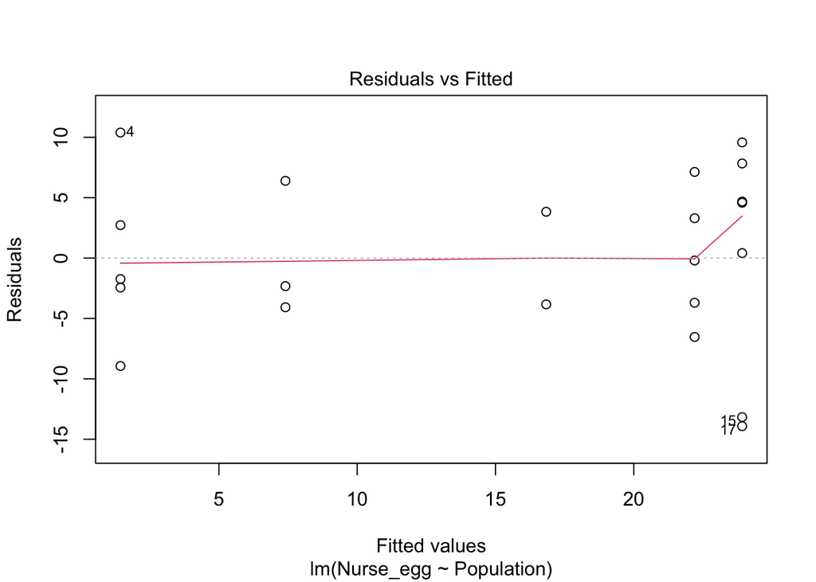

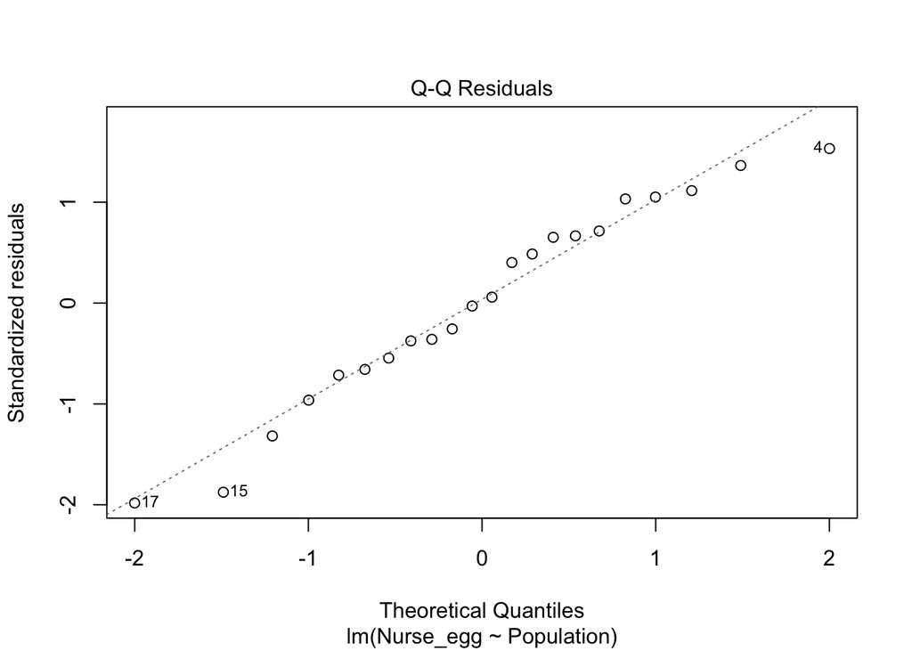

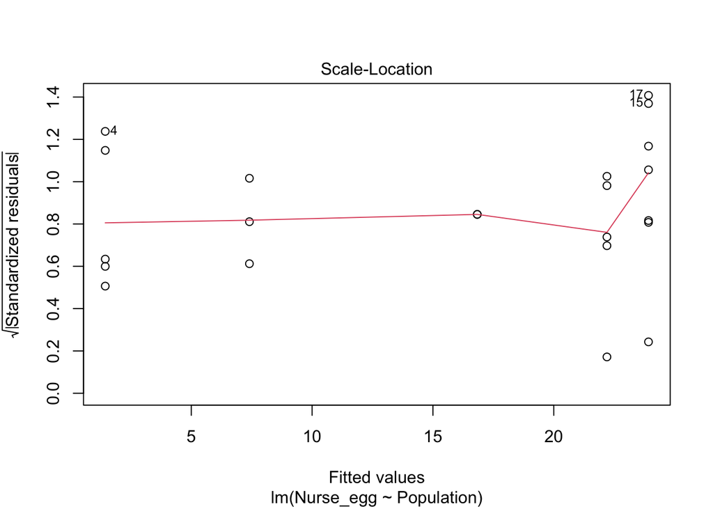

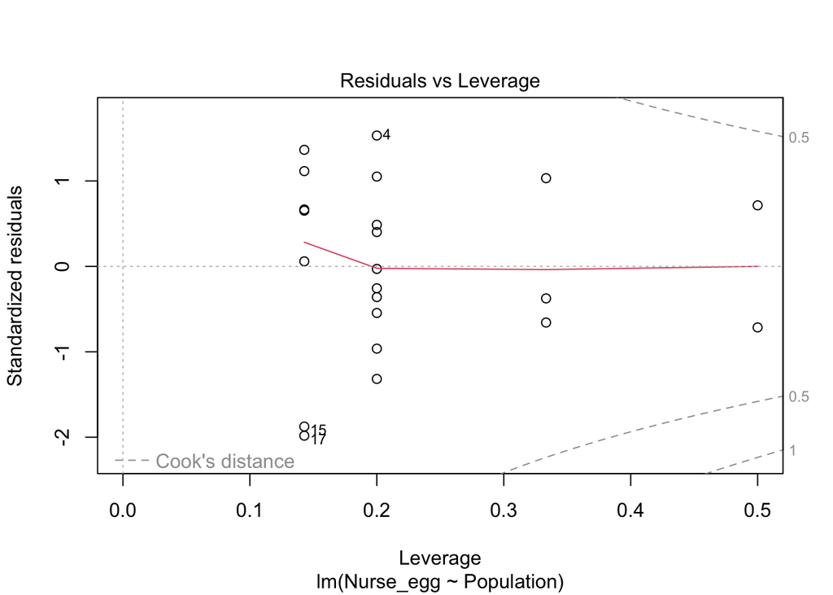

```r
plot(nurse_lm)
```

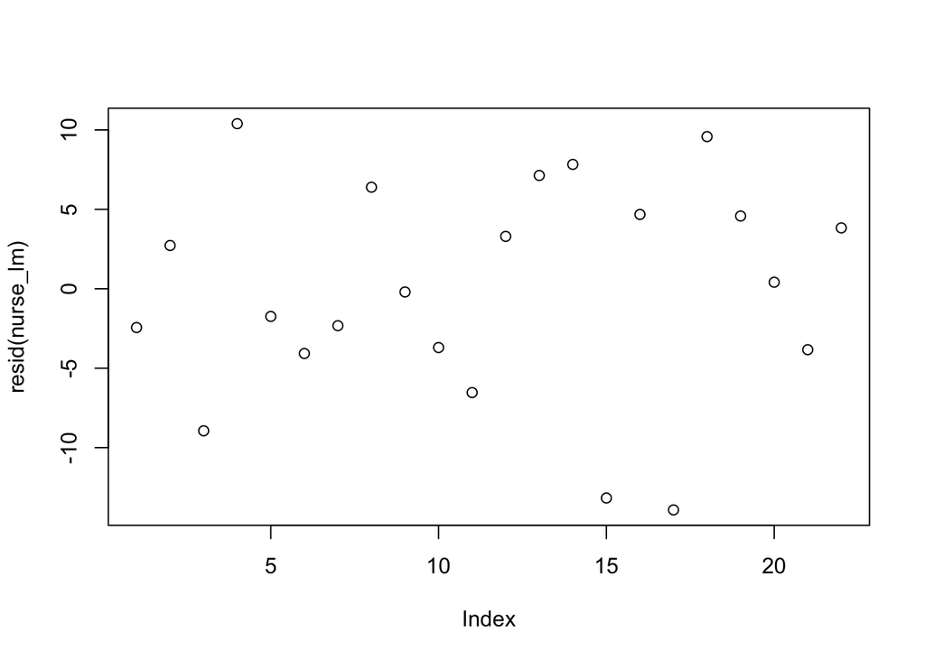

```r
plot(resid(nurse_lm))
```

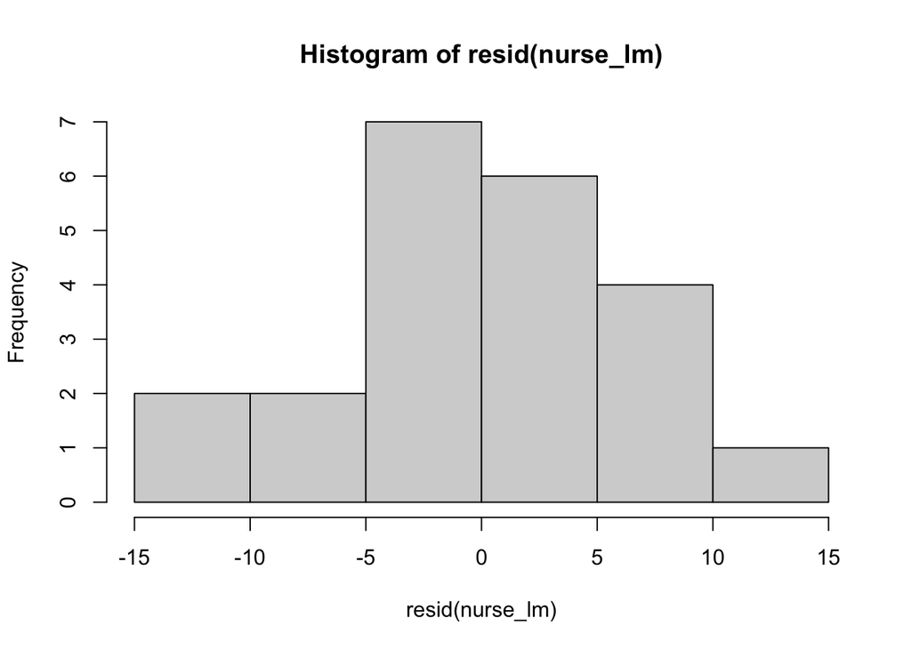

```r
hist(resid(nurse_lm))
```

Q-Q plot of model residuals

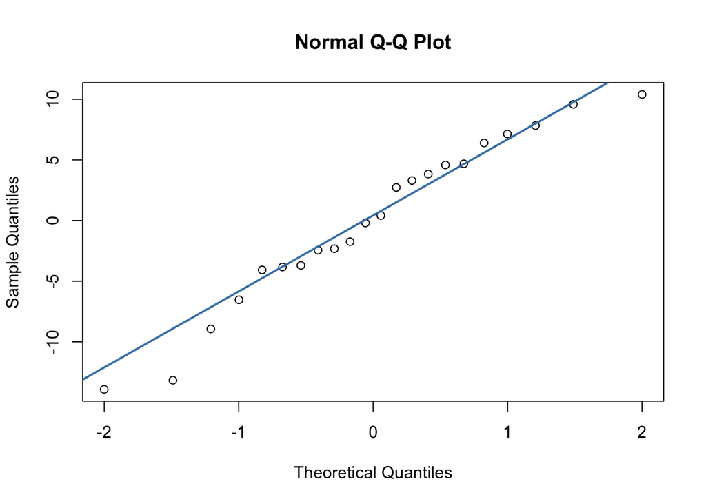

```r
qqnorm(resid(nurse_lm))
qqline(resid(nurse_lm), col = "steelblue", lwd = 2)
```

Isolate model estimates to plot on top of the raw data scatter

```r
emmeans(nurse_lm, "Population", type  = "response", data = nurse_eggs)
```

```
##  Population emmean   SE df lower.CL upper.CL
##  CB           1.44 3.39 17    -5.72      8.6
##  CM          16.83 5.36 17     5.52     28.1
##  DB          23.92 2.87 17    17.87     30.0
##  MB          22.20 3.39 17    15.04     29.4
##  RP           7.41 4.38 17    -1.83     16.6
##
## Confidence level used: 0.95
```

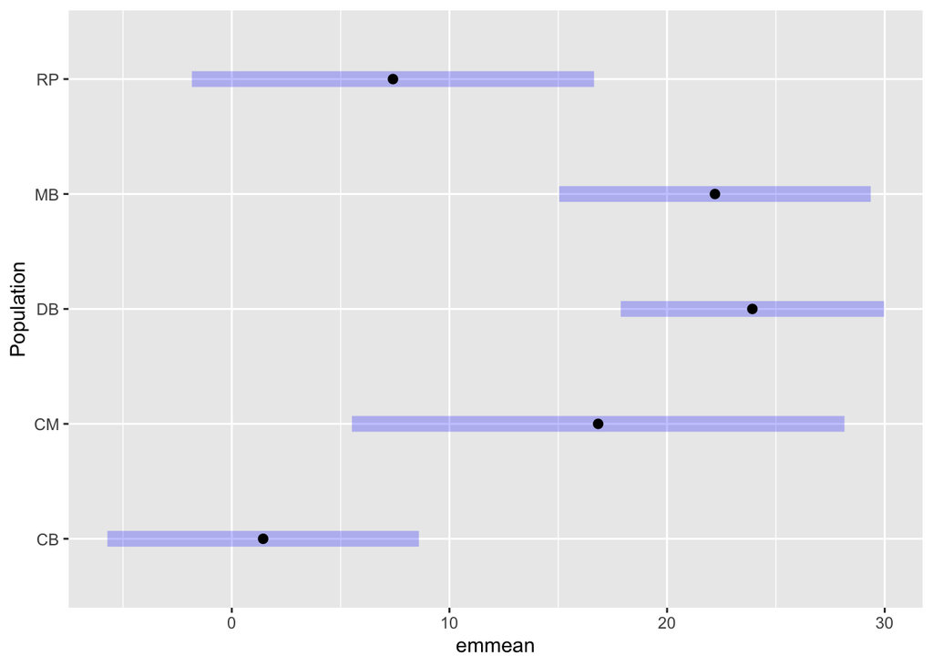

```r
estimates <- emmeans(nurse_lm, "Population", type  = "response", data = nurse_eggs)

plot(estimates)
```

```r
estimates
```

```
##  Population emmean   SE df lower.CL upper.CL
##  CB           1.44 3.39 17    -5.72      8.6
##  CM          16.83 5.36 17     5.52     28.1
##  DB          23.92 2.87 17    17.87     30.0
##  MB          22.20 3.39 17    15.04     29.4
##  RP           7.41 4.38 17    -1.83     16.6
##
## Confidence level used: 0.95
```

Create a dataframe of the model estimates

```r
site <- c("CB", "CM", "DB", "MB", "RP")

est <- c(1.44, 16.83, 23.92, 22.20, 7.41)


err_high <- c(8.6, 28.1, 30.0, 29.4, 16.6)


err_low <- c(-5.72, 5.52, 17.87, 15.04, -1.83)


nurse <- data.frame(Population = site, Estimate = est, Error_high = err_high, Error_low = err_low)

nurse
```

```
##   Population Estimate Error_high Error_low
## 1         CB     1.44        8.6     -5.72
## 2         CM    16.83       28.1      5.52
## 3         DB    23.92       30.0     17.87
## 4         MB    22.20       29.4     15.04
## 5         RP     7.41       16.6     -1.83
```

Plot nurse egg ratios across populations

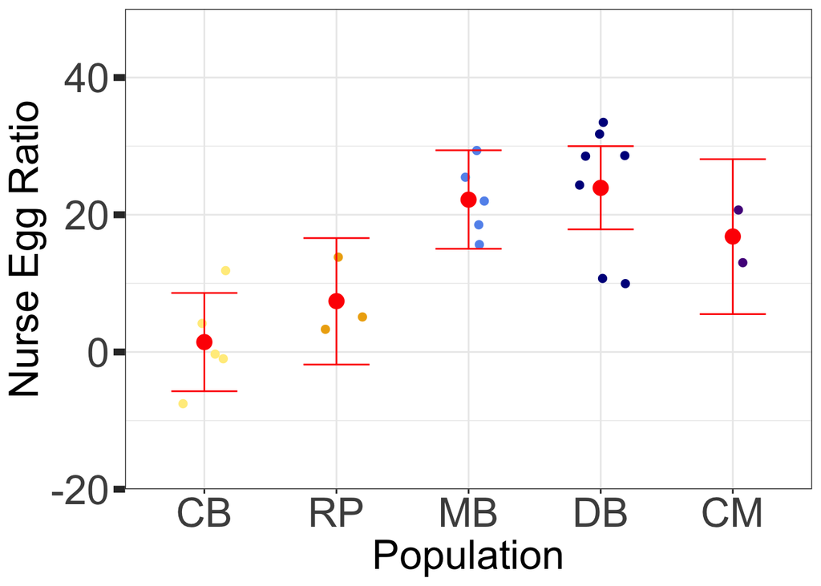

```r
ggplot(nurse_eggs, aes(x = Population, y = Nurse_egg, color = Population)) +
  geom_jitter(aes(x = Population, y = Nurse_egg), position=position_jitter(w=0.2), size = 2) +
  scale_color_manual(values = c("lightgoldenrod1", "darkgoldenrod2", "cornflowerblue","darkblue", "purple4")) +
  geom_point(data = nurse, aes(x = Population, y = Estimate), size = 4,  color = "red") +
  geom_errorbar(data = nurse, aes(x = Population, y = Estimate, ymin = Error_low, ymax = Error_high), color = "red", width = 0.5) +
  theme_bw() +
  theme(legend.position = "none",
        axis.title = element_text(size=25),
        axis.text = element_text(size=25),
        axis.ticks.y = element_line(linewidth = 2),
        axis.ticks.length.y = unit(0.25, "cm")) +
  scale_y_continuous(name = "Nurse Egg Ratio", expand = c(0,0), limits = c(-20,50)) +
  xlab("Population") -> nurse_egg_plot


nurse_egg_plot$data$Population <- factor(nurse_egg_plot$data$Population, levels=neworder)

nurse_egg_plot
```

## Analyses for Lab-Reared Egg Capsules

### Embryo Number

Import data

```r
embryo_number <- read.csv("/Users/keiramonuki/Documents/Sanford\ Lab/snail_tank_experiment/cap_len_emb_num_new.csv")

head(embryo_number)
```

```
##         ID Population Treatment Breeding_Pair Capsule_Num Capsule_Length
## 1 DB_H23_4         DB         H            23           4          5.253
## 2 DB_H23_5         DB         H            23           5          6.111
## 3 DB_H23_6         DB         H            23           6          5.370
## 4 DB_H23_7         DB         H            23           7          5.983
## 5 DB_H23_8         DB         H            23           8          6.046
## 6  DB_H4_1         DB         H             4           1          5.248
##   Number_embryos Avg_Size Scaled_caplen Scaled_embnum
## 1             25     30.1     0.1745183     0.8305648
## 2             57     30.1     0.2030233     1.8936877
## 3             59     30.1     0.1784053     1.9601329
## 4             70     30.1     0.1987708     2.3255814
## 5             61     30.1     0.2008638     2.0265781
## 6             52     21.3     0.2463850     2.4413146
```

Remove data from cold treatment and from RP population (not enough data for either), and the large DB snail (DB_H23)

```r
embryo_number %>%
  filter(Treatment == "H") %>%
  filter(Population != "RP") %>%
  filter(Breeding_Pair != "23") -> embryo_number

head(embryo_number)
```

```
##         ID Population Treatment Breeding_Pair Capsule_Num Capsule_Length
## 1  DB_H4_1         DB         H             4           1          5.248
## 2  DB_H4_2         DB         H             4           2          5.412
## 3  DB_H4_3         DB         H             4           3          4.821
## 4  DB_H4_4         DB         H             4           4          5.428
## 5  DB_H4_5         DB         H             4           5          4.821
## 6 DB_H10_1         DB         H            10           1          5.543
##   Number_embryos Avg_Size Scaled_caplen Scaled_embnum
## 1             52     21.3     0.2463850      2.441315
## 2             60     21.3     0.2540845      2.816901
## 3             44     21.3     0.2263380      2.065728
## 4             67     21.3     0.2548357      3.145540
## 5             40     21.3     0.2263380      1.877934
## 6             66     25.3     0.2190909      2.608696
```

Check distribution of raw data, including mean and standard deviation

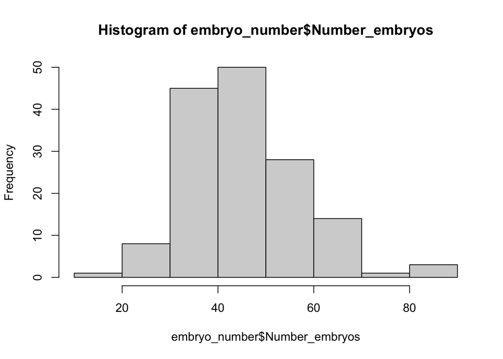

```r
hist(embryo_number$Number_embryos)
```

```r
mean(embryo_number$Number_embryos)
```

```
## [1] 46.11333
```

```r
sd(embryo_number$Number_embryos)
```

```
## [1] 12.39914
```

Run a GLMM with a negative binomial distribution, size and population fixed effects, breeding pair as a random effect, and a log link function. Calculate AIC values

```r
emb_num_nb <-
  glm.nb(Number_embryos ~ Avg_Size + Population + (1 | Breeding_Pair), data = embryo_number)

summary(emb_num_nb)
```

```
##
## Call:
## glm.nb(formula = Number_embryos ~ Avg_Size + Population + (1 |
##     Breeding_Pair), data = embryo_number, init.theta = 31.73672474,
##     link = log)
##
## Coefficients: (1 not defined because of singularities)
##                       Estimate Std. Error z value Pr(>|z|)
## (Intercept)            2.69465    0.25701  10.484  < 2e-16 ***
## Avg_Size               0.05279    0.01144   4.614 3.94e-06 ***
## PopulationMB           0.03975    0.04561   0.872    0.383
## PopulationYB          -0.05071    0.05442  -0.932    0.351
## 1 | Breeding_PairTRUE       NA         NA      NA       NA
## ---
## Signif. codes:  0 '***' 0.001 '**' 0.01 '*' 0.05 '.' 0.1 ' ' 1
##
## (Dispersion parameter for Negative Binomial(31.7367) family taken to be 1)
##
##     Null deviance: 198.63  on 149  degrees of freedom
## Residual deviance: 151.13  on 146  degrees of freedom
## AIC: 1139.9
##
## Number of Fisher Scoring iterations: 1
##
##
##               Theta:  31.74
##           Std. Err.:  6.22
##
##  2 x log-likelihood:  -1129.89
```

```r
anova(emb_num_nb)
```

```
## Analysis of Deviance Table
##
## Model: Negative Binomial(31.7367), link: log
##
## Response: Number_embryos
##
## Terms added sequentially (first to last)
##
##
##                   Df Deviance Resid. Df Resid. Dev  Pr(>Chi)
## NULL                                149     198.63
## Avg_Size           1   44.762       148     153.87 2.225e-11 ***
## Population         2    2.740       146     151.12    0.2541
## 1 | Breeding_Pair  0    0.000       146     151.12
## ---
## Signif. codes:  0 '***' 0.001 '**' 0.01 '*' 0.05 '.' 0.1 ' ' 1
```

```r
Anova(emb_num_nb)
```

```
## Analysis of Deviance Table (Type II tests)
##
## Response: Number_embryos
##                   LR Chisq Df Pr(>Chisq)
## Avg_Size           21.2482  1  4.035e-06 ***
## Population          2.7399  2     0.2541
## 1 | Breeding_Pair           0
## ---
## Signif. codes:  0 '***' 0.001 '**' 0.01 '*' 0.05 '.' 0.1 ' ' 1
```

```r
AIC(emb_num_nb)
```

```
## [1] 1139.89
```

```r
AICc(emb_num_nb)
```

```
## [1] 1140.306
```

Back-transform model estimates to plot on top of the raw data scatter

```r
emmeans(emb_num_nb, "Population", type  = "response", data = embryo_number)
```

```
##  Population response   SE  df asymp.LCL asymp.UCL
##  DB             45.9 1.55 Inf      43.0        49
##  MB             47.8 1.61 Inf      44.7        51
##  YB             43.6 1.67 Inf      40.5        47
##
## Confidence level used: 0.95
## Intervals are back-transformed from the log scale
```

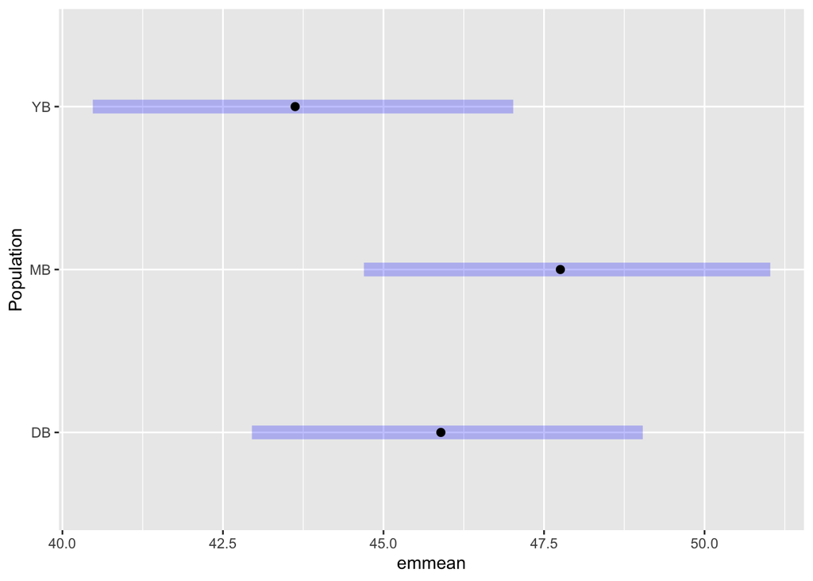

```r
estimates <- emmeans(emb_num_nb, "Population", type  = "response", data = embryo_number)

plot(estimates)
```

```r
estimates
```

```
##  Population response   SE  df asymp.LCL asymp.UCL
##  DB             45.9 1.55 Inf      43.0        49
##  MB             47.8 1.61 Inf      44.7        51
##  YB             43.6 1.67 Inf      40.5        47
##
## Confidence level used: 0.95
## Intervals are back-transformed from the log scale
```

Create data frame of the back-transformed model estimates

```r
site <- c("DB", "MB", "YB")

est <- c(45.9, 47.8, 43.6)
err_high <- c(49, 51, 47)
err_low <- c(43.0, 44.7, 40.5)

emb_num <- data.frame(Population = site, Estimate = est, Error_high = err_high, Error_low = err_low)
emb_num
```

```
##   Population Estimate Error_high Error_low
## 1         DB     45.9         49      43.0
## 2         MB     47.8         51      44.7
## 3         YB     43.6         47      40.5
```

Plot the number of embryos across populations

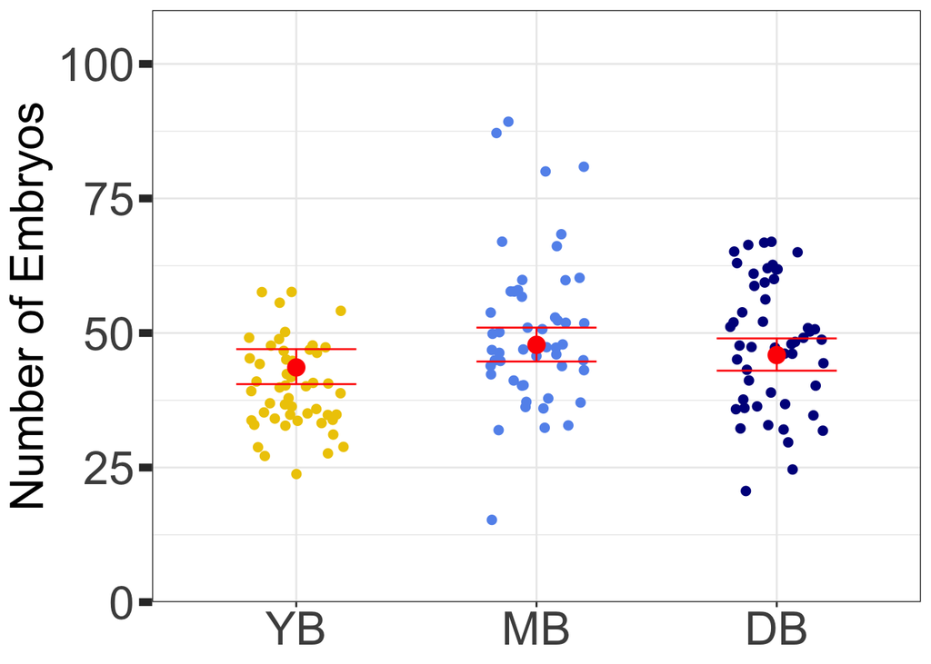

```r
ggplot(embryo_number, aes(x = Population, y = Number_embryos, color = Population)) +
  geom_jitter(aes(x = Population, y = Number_embryos), position=position_jitter(w=0.2), size = 2) +
  scale_color_manual(values = c("gold2", "cornflowerblue","darkblue")) +
  geom_point(data = emb_num, aes(x = Population, y = Estimate), size = 4,  color = "red") +
  geom_errorbar(data = emb_num, aes(x = Population, y = Estimate, ymin = Error_low, ymax = Error_high), color = "red", width = 0.5) +
  theme_bw() +
   theme(legend.position = "none",
         axis.title.x = element_blank(),
         axis.title.y = element_text(size=25),
        axis.text = element_text(size=25),
        axis.ticks.y = element_line(linewidth = 2),
        axis.ticks.length.y = unit(0.25, "cm")) +
  scale_y_continuous(name = "Number of Embryos", expand = c(0,0), limits = c(0,110))  -> emb_num_plot


neworder = c("YB", "MB", "DB")

emb_num_plot$data$Population <- factor(emb_num_plot$data$Population, levels=neworder)

emb_num_plot
```

Calculate pairwise comparisons using emmeans and Tukey adjustments

```r
em <- emmeans(emb_num_nb, "Population", data = embryo_number)
contrast(em, "pairwise", adjust = "Tukey")
```

```
##  contrast estimate     SE  df z.ratio p.value
##  DB - MB   -0.0398 0.0456 Inf  -0.872  0.6583
##  DB - YB    0.0507 0.0544 Inf   0.932  0.6200
##  MB - YB    0.0905 0.0547 Inf   1.655  0.2227
##
## Results are given on the log (not the response) scale.
## P value adjustment: tukey method for comparing a family of 3 estimates
```

```r
#  DB - MB   -0.0398 0.0456 Inf  -0.872  0.6583
# DB - YB    0.0507 0.0544 Inf   0.932  0.6200
# MB - YB    0.0905 0.0547 Inf   1.655  0.2227
```

Plot model residuals to assess model fit

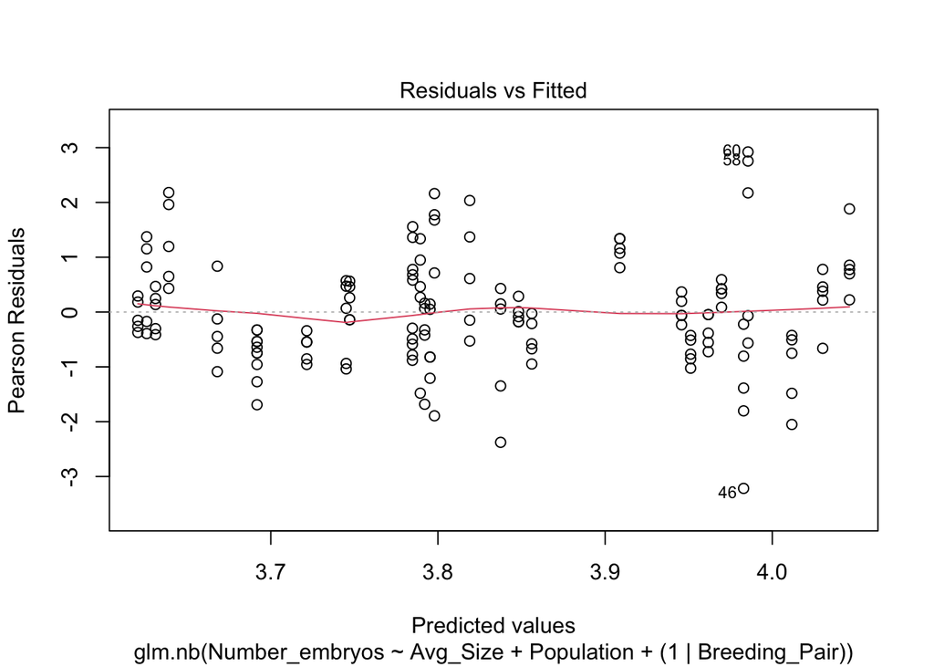

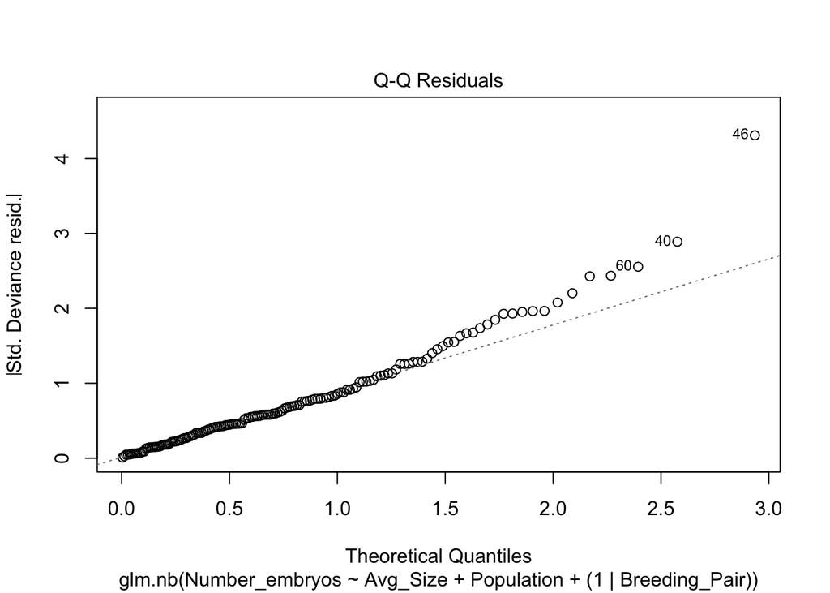

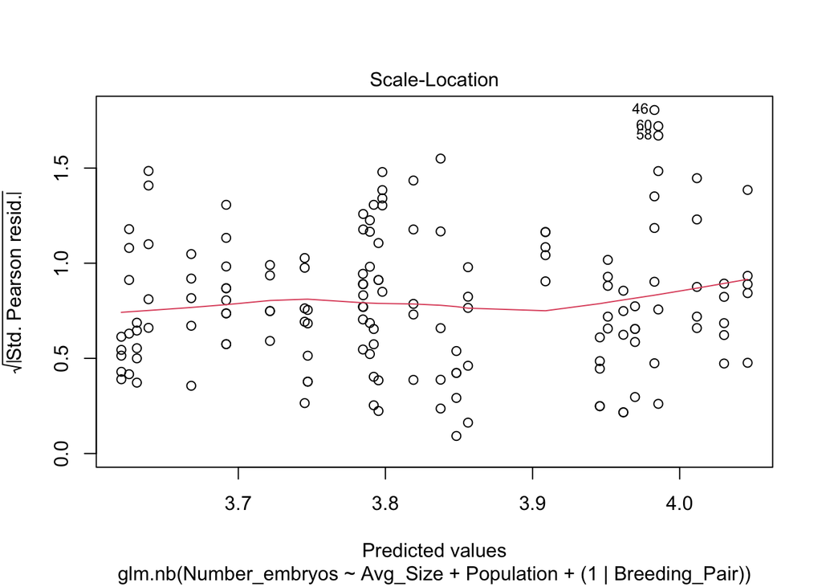

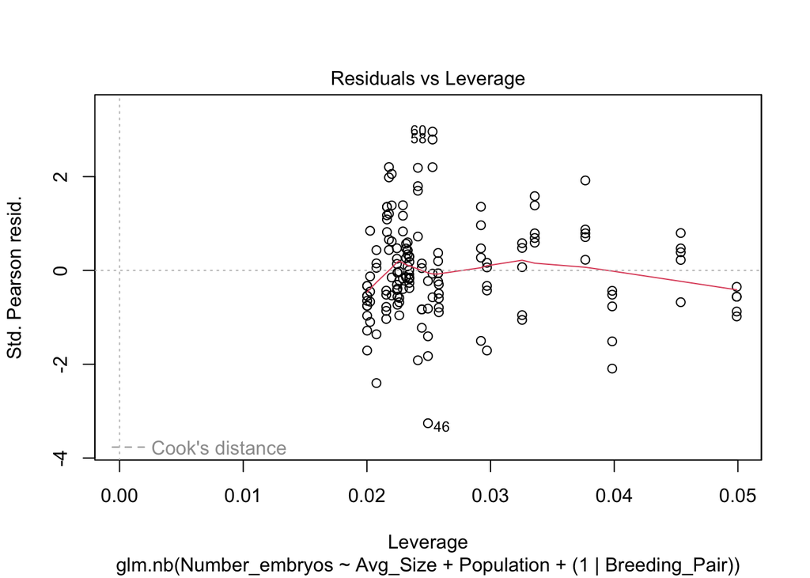

```r
plot(emb_num_nb)
```

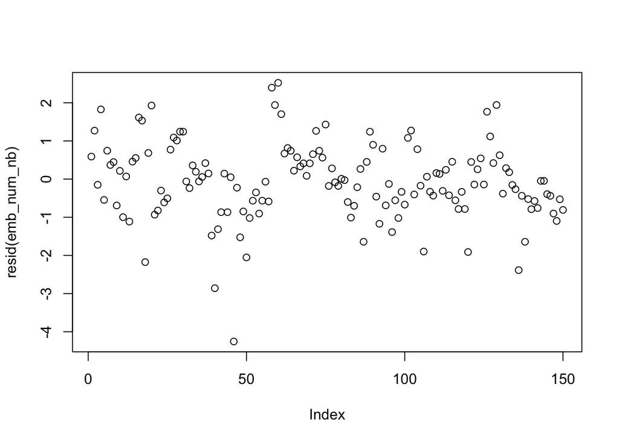

```r
plot(resid(emb_num_nb))
```

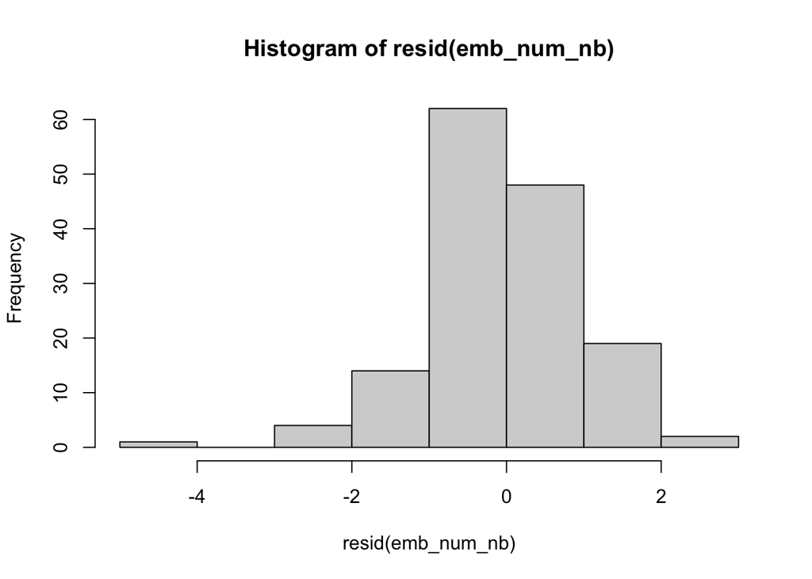

```r
hist(resid(emb_num_nb))
```

Q-Q plot of model residuals

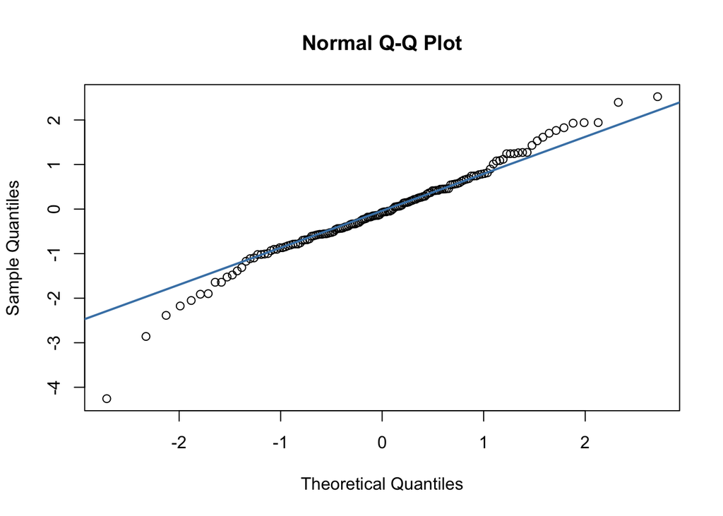

```r
qqnorm(resid(emb_num_nb))
qqline(resid(emb_num_nb), col = "steelblue", lwd = 2)
```

### Capsule Length

Capsule ength is in the embryo number dataset. Assess the distribution of the raw data, including mean and standard deviation.

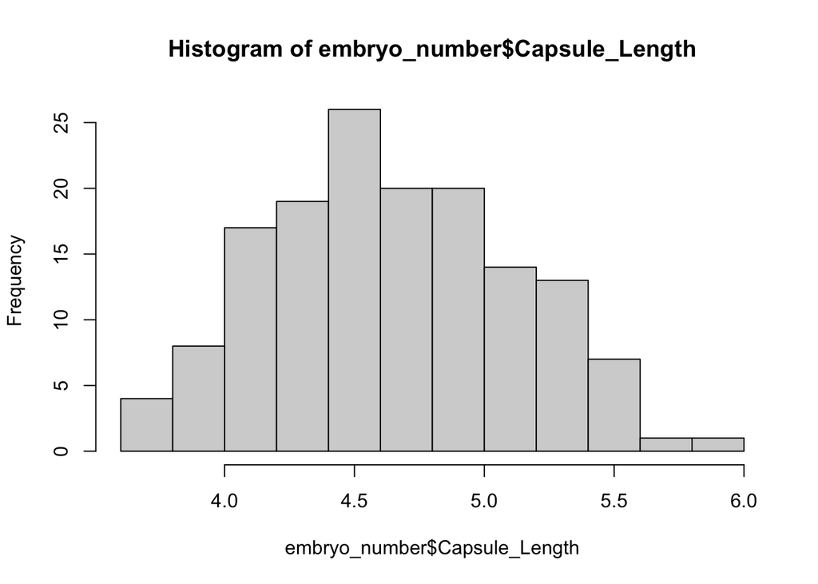

```r
hist(embryo_number$Capsule_Length)
```

```r
mean(embryo_number$Capsule_Length)
```

```
## [1] 4.645653
```

```r
sd(embryo_number$Capsule_Length)
```

```
## [1] 0.4639342
```

Run a GLMM with a gamma distribution and log link function and calculate AIC values.

```r
cap_len_gm <-
  glm(Capsule_Length ~ Avg_Size + Population + (1 | Breeding_Pair), family = Gamma(link = "log"), data = embryo_number)

summary(cap_len_gm)
```

```
##
## Call:
## glm(formula = Capsule_Length ~ Avg_Size + Population + (1 | Breeding_Pair),
##     family = Gamma(link = "log"), data = embryo_number)
##
## Coefficients: (1 not defined because of singularities)
##                       Estimate Std. Error t value Pr(>|t|)
## (Intercept)           0.724094   0.084930   8.526 1.75e-14 ***
## Avg_Size              0.036829   0.003791   9.714  < 2e-16 ***
## PopulationMB          0.016340   0.015227   1.073   0.2850
## PopulationYB          0.043888   0.017756   2.472   0.0146 *
## 1 | Breeding_PairTRUE       NA         NA      NA       NA
## ---
## Signif. codes:  0 '***' 0.001 '**' 0.01 '*' 0.05 '.' 0.1 ' ' 1
##
## (Dispersion parameter for Gamma family taken to be 0.005794824)
##
##     Null deviance: 1.48860  on 149  degrees of freedom
## Residual deviance: 0.82864  on 146  degrees of freedom
## AIC: 115.32
##
## Number of Fisher Scoring iterations: 4
```

```r
anova(cap_len_gm)
```

```
## Analysis of Deviance Table
##
## Model: Gamma, link: log
##
## Response: Capsule_Length
##
## Terms added sequentially (first to last)
##
##
##                   Df Deviance Resid. Df Resid. Dev        F  Pr(>F)
## NULL                                149    1.48860
## Avg_Size           1  0.62488       148    0.86372 107.8347 < 2e-16 ***
## Population         2  0.03508       146    0.82864   3.0267 0.05153 .
## 1 | Breeding_Pair  0  0.00000       146    0.82864
## ---
## Signif. codes:  0 '***' 0.001 '**' 0.01 '*' 0.05 '.' 0.1 ' ' 1
```

```r
Anova(cap_len_gm)
```

```
## Analysis of Deviance Table (Type II tests)
##
## Response: Capsule_Length
##                   LR Chisq Df Pr(>Chisq)
## Avg_Size            94.035  1    < 2e-16 ***
## Population           6.053  2    0.04848 *
## 1 | Breeding_Pair           0
## ---
## Signif. codes:  0 '***' 0.001 '**' 0.01 '*' 0.05 '.' 0.1 ' ' 1
```

```r
AICc(cap_len_gm)
```

```
## [1] 115.7365
```

```r
AIC(cap_len_gm)
```

```
## [1] 115.3198
```

Back-transform the model estimates to plot on top of the raw data scatter

```r
emmeans(cap_len_gm, "Population", type  = "response", data = embryo_number)
```

```
##  Population response     SE  df lower.CL upper.CL
##  DB             4.54 0.0507 146     4.44     4.64
##  MB             4.62 0.0519 146     4.52     4.72
##  YB             4.75 0.0589 146     4.63     4.87
##
## Confidence level used: 0.95
## Intervals are back-transformed from the log scale
```

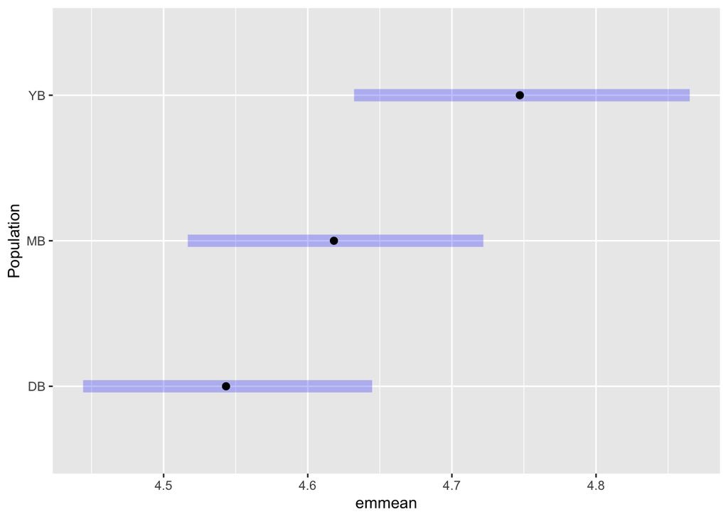

```r
estimates <- emmeans(cap_len_gm, "Population", type  = "response", data = embryo_number)

plot(estimates)
```

```r
estimates
```

```
##  Population response     SE  df lower.CL upper.CL
##  DB             4.54 0.0507 146     4.44     4.64
##  MB             4.62 0.0519 146     4.52     4.72
##  YB             4.75 0.0589 146     4.63     4.87
##
## Confidence level used: 0.95
## Intervals are back-transformed from the log scale
```

Create data frame of the back-transformed model estimates

```r
site <- c("DB", "MB", "YB")

est <- c(4.54, 4.62, 4.75)
err_high <- c(4.64, 4.72, 4.87)
err_low <- c(4.44, 4.52, 4.63)

cap_len <- data.frame(Population = site, Estimate = est, Error_high = err_high, Error_low = err_low)
cap_len
```

```
##   Population Estimate Error_high Error_low
## 1         DB     4.54       4.64      4.44
## 2         MB     4.62       4.72      4.52
## 3         YB     4.75       4.87      4.63
```

Plot capsule length across populations

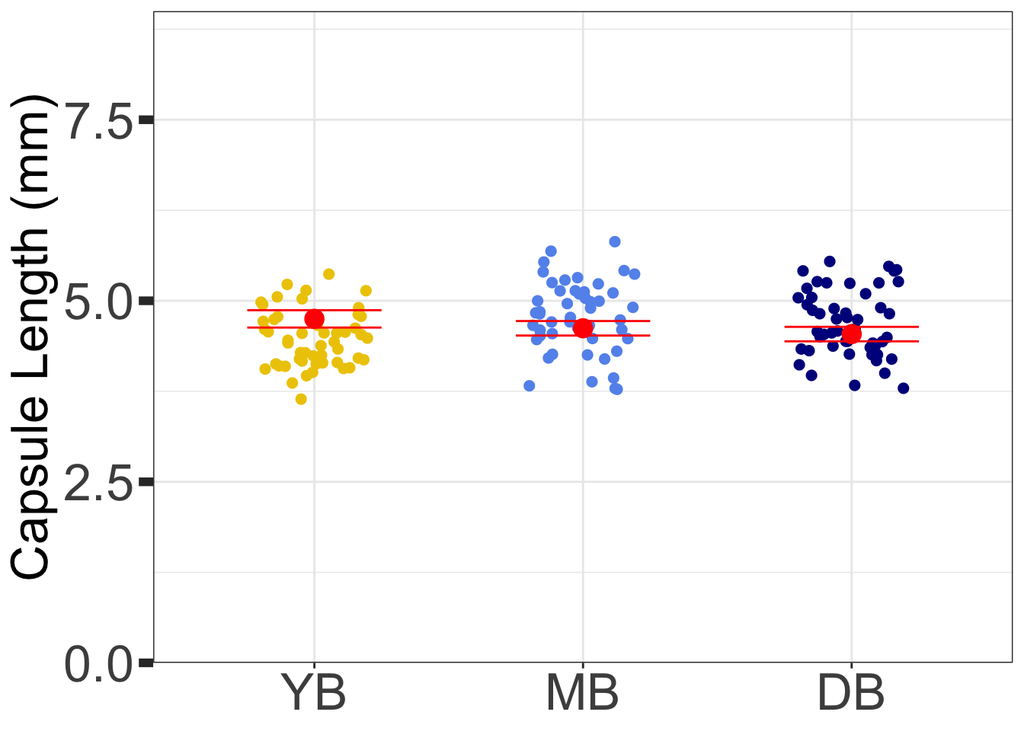

```r
ggplot(embryo_number, aes(x = Population, y = Capsule_Length, color = Population)) +
  geom_jitter(aes(x = Population, y = Capsule_Length), position=position_jitter(w=0.2), size = 2) +
  scale_color_manual(values = c("gold2", "cornflowerblue","darkblue")) +
  geom_point(data = cap_len, aes(x = Population, y = Estimate), size = 4,  color = "red") +
  geom_errorbar(data = cap_len, aes(x = Population, y = Estimate, ymin = Error_low, ymax = Error_high), color = "red", width = 0.5) +
  theme_bw() +
  theme(legend.position = "none",
        axis.title.x = element_blank(),
        axis.title.y = element_text(size=25),
        axis.text = element_text(size=25),
        axis.ticks.y = element_line(linewidth = 2),
        axis.ticks.length.y = unit(0.25, "cm")) +
  scale_y_continuous(name = "Capsule Length (mm)", expand = c(0,0), limits = c(0,9)) -> cap_len_plot

cap_len_plot$data$Population <- factor(cap_len_plot$data$Population, levels=neworder)

cap_len_plot
```

Calculate pairwise comparisons using emmeans and Tukey adjustments

```r
em <- emmeans(cap_len_gm, "Population", data = embryo_number)
contrast(em, "pairwise", adjust = "Tukey")
```

```
##  contrast estimate     SE  df t.ratio p.value
##  DB - MB   -0.0163 0.0152 146  -1.073  0.5322
##  DB - YB   -0.0439 0.0178 146  -2.472  0.0386
##  MB - YB   -0.0275 0.0179 146  -1.540  0.2752
##
## Results are given on the log (not the response) scale.
## P value adjustment: tukey method for comparing a family of 3 estimates
```

Plot model residuals to assess model fit

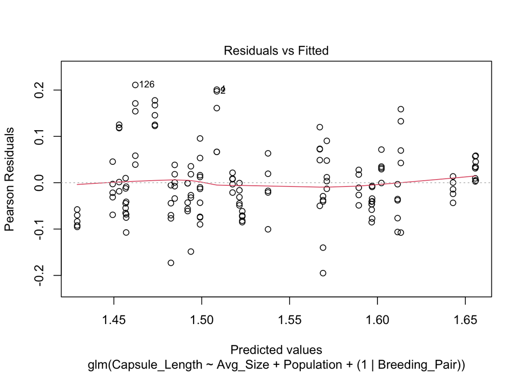

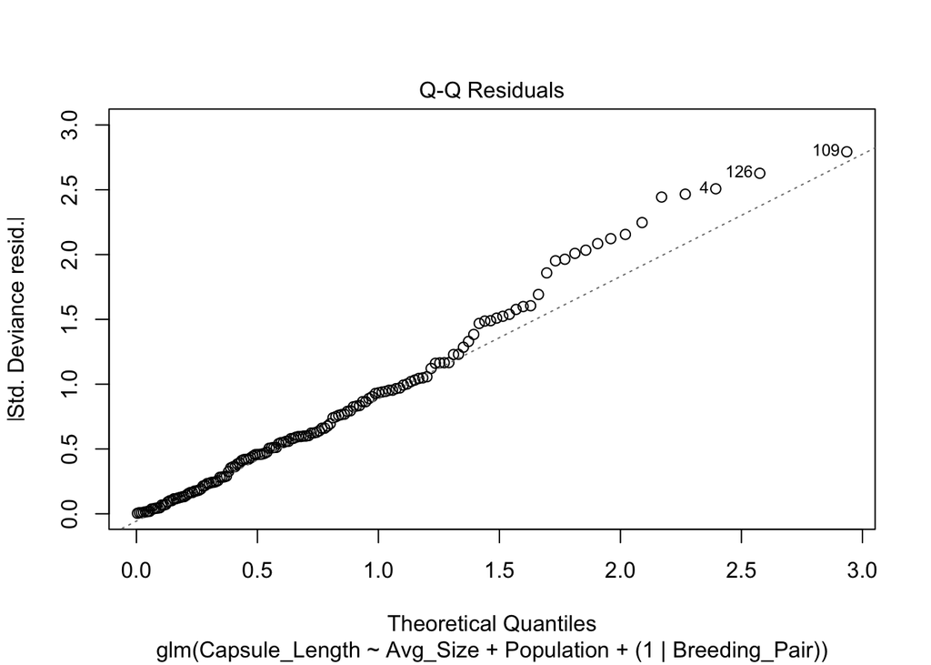

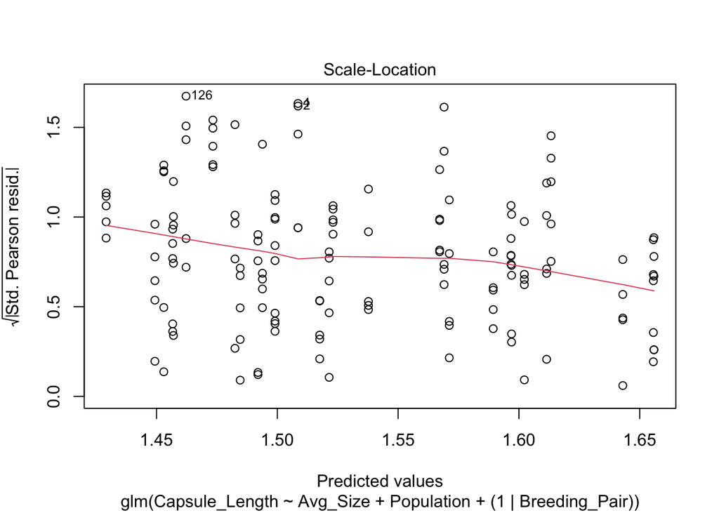

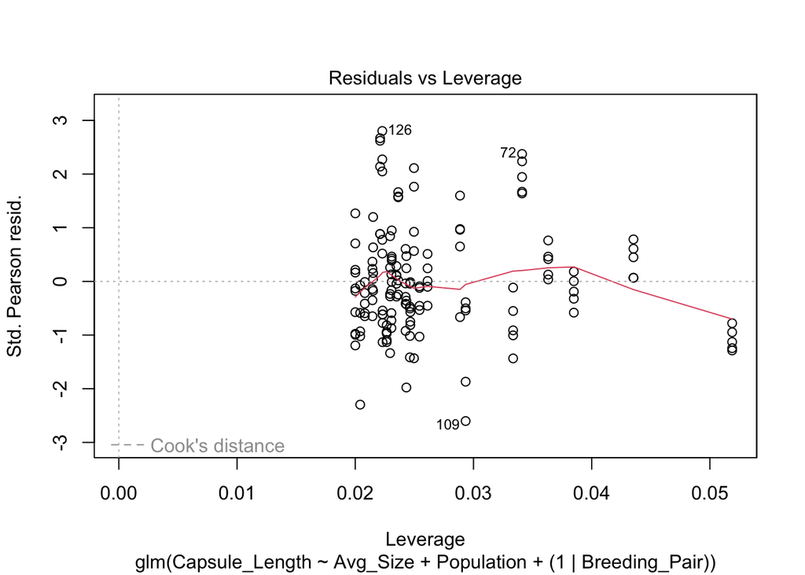

```r
plot(cap_len_gm)
```

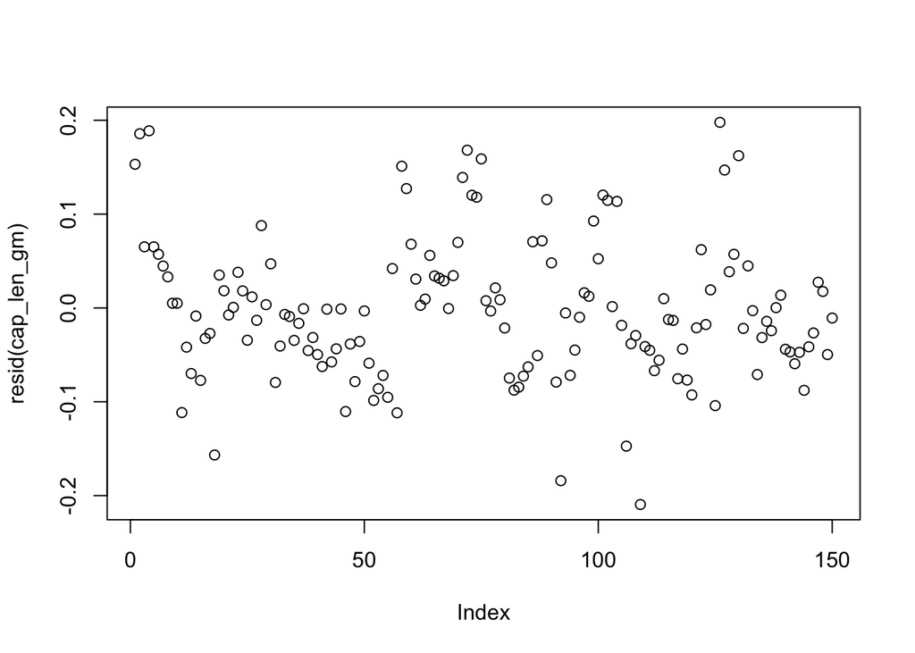

```r
plot(resid(cap_len_gm))
```

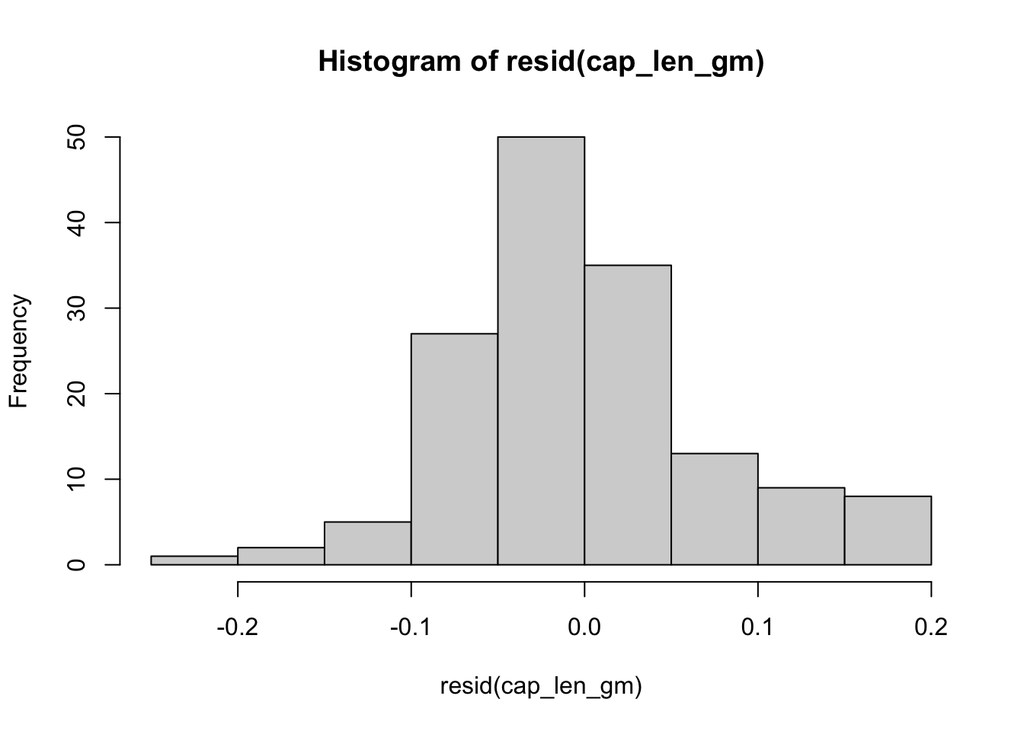

```r
hist(resid(cap_len_gm))
```

Q-Q plot for model residuals

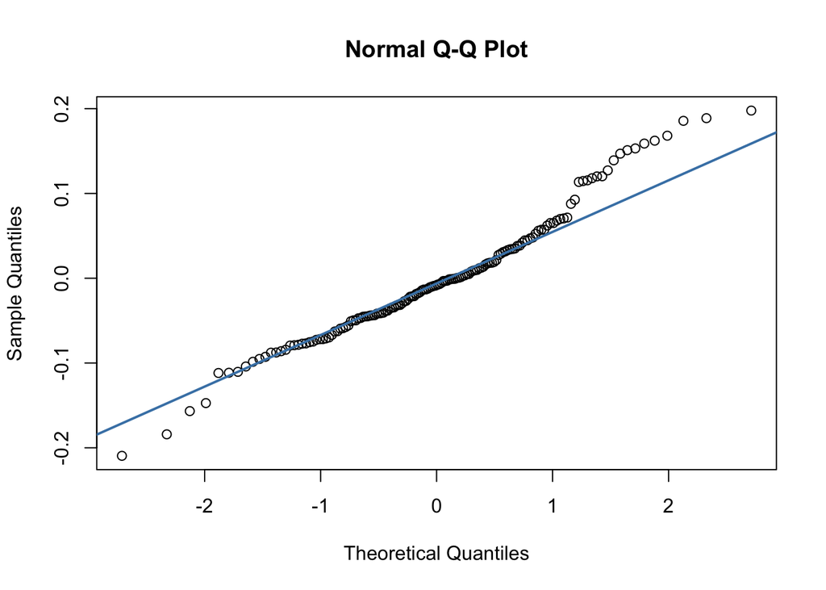

```r
qqnorm(resid(cap_len_gm))
qqline(resid(cap_len_gm), col = "steelblue", lwd = 2)
```

### Embryo size

Import data

```r
embryo_size <- read.csv("/Users/keiramonuki/Documents/Sanford\ Lab/snail_tank_experiment/emb_size_new.csv")

head(embryo_size)
```

```
##         ID Population Treatment Breeding_Pair Breeding_Pair_new Capsule_num
## 1 DB_H23_4         DB         H            23                 1           4
## 2 DB_H23_4         DB         H            23                 1           4
## 3 DB_H23_4         DB         H            23                 1           4
## 4 DB_H23_4         DB         H            23                 1           4
## 5 DB_H23_4         DB         H            23                 1           4
## 6 DB_H23_4         DB         H            23                 1           4
##   Hatch_ID Embryo_size Avg_Size
## 1        1       0.296     30.1
## 2        2       0.284     30.1
## 3        3       0.311     30.1
## 4        4       0.231     30.1
## 5        5       0.324     30.1
## 6        6       0.257     30.1
```

Remove data from cold treatment and from RP population (not enough data for either), and from DB_H23

```r
embryo_size %>%
  filter(Treatment == "H") %>%
  filter(Population != "RP") %>%
  filter(Breeding_Pair != "23")-> embryo_size

head(embryo_size)
```

```
##        ID Population Treatment Breeding_Pair Breeding_Pair_new Capsule_num
## 1 MB_H7_1         MB         H             7                 2           1
## 2 MB_H7_1         MB         H             7                 2           1
## 3 MB_H7_1         MB         H             7                 2           1
## 4 MB_H7_1         MB         H             7                 2           1
## 5 MB_H7_1         MB         H             7                 2           1
## 6 MB_H7_1         MB         H             7                 2           1
##   Hatch_ID Embryo_size Avg_Size
## 1        1       0.317    23.65
## 2        2       0.321    23.65
## 3        3       0.268    23.65
## 4        4       0.282    23.65
## 5        5       0.278    23.65
## 6        6       0.260    23.65
```

Assess raw data distribution, including mean and standard deviation

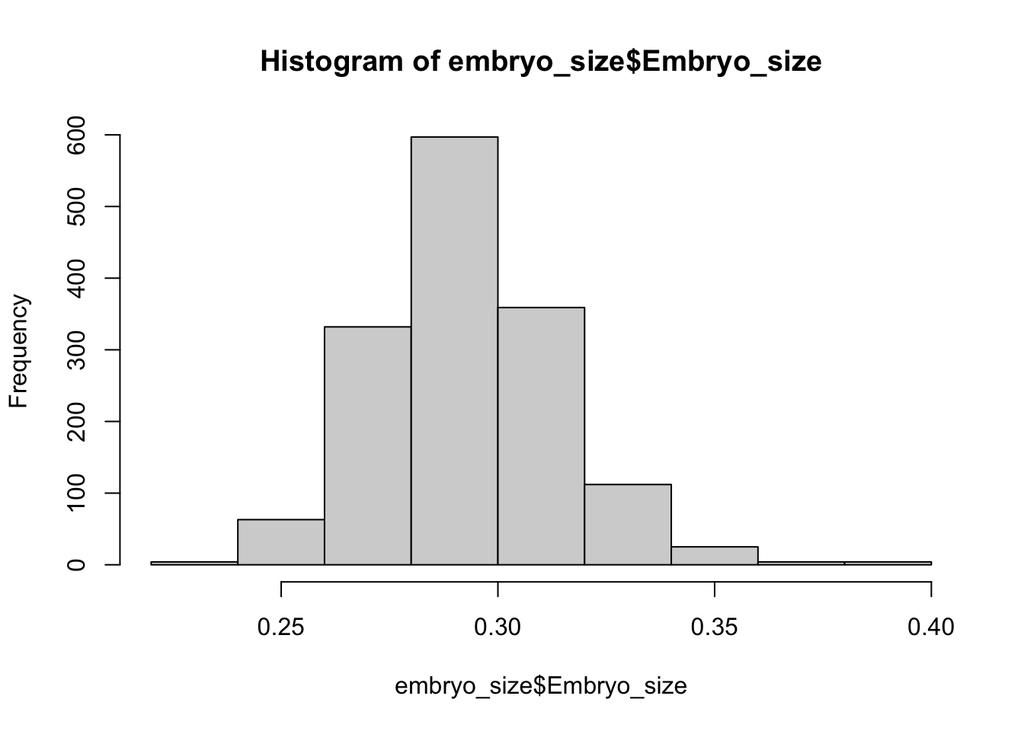

```r
hist(embryo_size$Embryo_size)
```

```r
mean(embryo_size$Embryo_size)
```

```
## [1] 0.2936593
```

```r
sd(embryo_size$Embryo_size)
```

```
## [1] 0.02102924
```

Run a linear mixed effects model with Capsule ID (i.e. “Capsule_num”) nested within Breeding Pair

```r
emb_size_lm1 <- lmer(Embryo_size ~ Avg_Size + Population + (1 | Breeding_Pair/Capsule_num), data = embryo_size)

summary(emb_size_lm1)
```

```
## Linear mixed model fit by REML ['lmerMod']
## Formula: Embryo_size ~ Avg_Size + Population + (1 | Breeding_Pair/Capsule_num)
##    Data: embryo_size
##
## REML criterion at convergence: -7559.2
##
## Scaled residuals:
##     Min      1Q  Median      3Q     Max
## -2.7909 -0.6636 -0.0489  0.5942  4.4089
##
## Random effects:
##  Groups                    Name        Variance  Std.Dev.
##  Capsule_num:Breeding_Pair (Intercept) 5.809e-05 0.007621
##  Breeding_Pair             (Intercept) 5.038e-05 0.007098
##  Residual                              3.336e-04 0.018264
## Number of obs: 1500, groups:  Capsule_num:Breeding_Pair, 100; Breeding_Pair, 20
##
## Fixed effects:
##               Estimate Std. Error t value
## (Intercept)  2.848e-01  1.031e-02  27.619
## Avg_Size     1.593e-04  4.776e-04   0.334
## PopulationMB 8.974e-05  1.576e-03   0.057
## PopulationYB 1.501e-02  1.643e-03   9.133
##
## Correlation of Fixed Effects:
##             (Intr) Avg_Sz PpltMB
## Avg_Size    -0.980
## PopulatinMB  0.150 -0.228
## PopulatinYB -0.194  0.117  0.487
```

```r
anova(emb_size_lm1) #size not significant:0.83292
```

```
## Analysis of Variance Table
##            npar   Sum Sq   Mean Sq F value
## Avg_Size      1 0.002155 0.0021554  6.4617
## Population    2 0.036273 0.0181363 54.3710
```

```r
Anova(emb_size_lm1) #chisq = 7.0694, 0.02917
```

```
## Analysis of Deviance Table (Type II Wald chisquare tests)
##
## Response: Embryo_size
##               Chisq Df Pr(>Chisq)
## Avg_Size     0.1113  1     0.7386
## Population 108.7420  2     <2e-16 ***
## ---
## Signif. codes:  0 '***' 0.001 '**' 0.01 '*' 0.05 '.' 0.1 ' ' 1
```

```r
AIC(emb_size_lm1) #-7635.207
```

```
## [1] -7545.244
```

```r
AICc(emb_size_lm1) #-7635.132
```

```
## [1] -7545.169
```

Calculate pairwise comparisons using emmeans and Tukey adjustments

```r
em <- emmeans(emb_size_lm1, "Population", data = embryo_size)
contrast(em, "pairwise", adjust = "Tukey")
```

```
##  contrast  estimate      SE   df t.ratio p.value
##  DB - MB  -8.97e-05 0.00159  845  -0.056  0.9982
##  DB - YB  -1.50e-02 0.00166 1042  -9.065  <.0001
##  MB - YB  -1.49e-02 0.00164 1196  -9.091  <.0001
##
## Degrees-of-freedom method: kenward-roger
## P value adjustment: tukey method for comparing a family of 3 estimates
```

Isolate model estimates to plot on top of raw data scatter

```r
emmeans(emb_size_lm1, "Population", type  = "response", data = embryo_size)
```

```
##  Population emmean      SE   df lower.CL upper.CL
##  DB          0.288 0.00206 27.0    0.284    0.292
##  MB          0.288 0.00205 27.2    0.284    0.293
##  YB          0.303 0.00209 29.4    0.299    0.308
##
## Degrees-of-freedom method: kenward-roger
## Confidence level used: 0.95
```

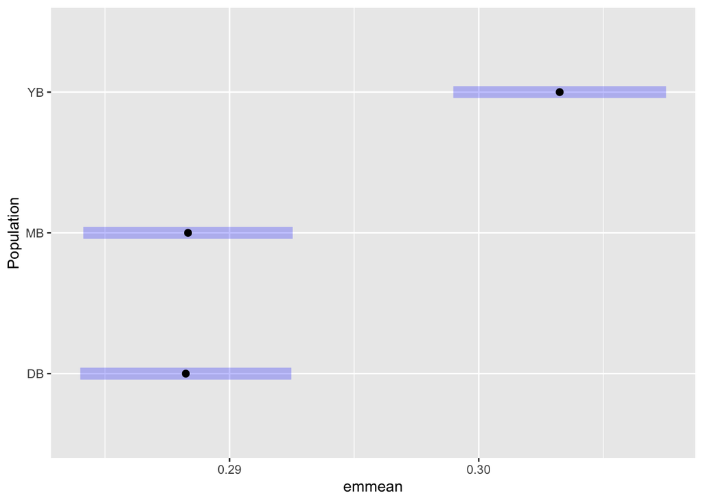

```r
estimates <- emmeans(emb_size_lm1, "Population", type  = "response", data = embryo_size)

plot(estimates)
```

```r
estimates
```

```
##  Population emmean      SE   df lower.CL upper.CL
##  DB          0.288 0.00206 27.0    0.284    0.292
##  MB          0.288 0.00205 27.2    0.284    0.293
##  YB          0.303 0.00209 29.4    0.299    0.308
##
## Degrees-of-freedom method: kenward-roger
## Confidence level used: 0.95
```

```r
est <- c(0.289, 0.292, 0.300)
err_high <- c(0.295, 0.297, 0.306)
err_low <- c(0.284, 0.286, 0.294)

emb_size <- data.frame(Population = site, Estimate = est, Error_high = err_high, Error_low = err_low)
emb_size
```

```
##   Population Estimate Error_high Error_low
## 1         DB    0.289      0.295     0.284
## 2         MB    0.292      0.297     0.286
## 3         YB    0.300      0.306     0.294
```

Plot embryo size across populations

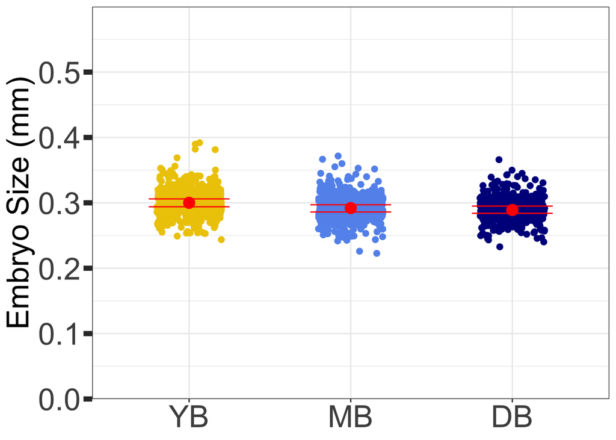

```r
ggplot(embryo_size, aes(x = Population, y = Embryo_size, color = Population)) +
  geom_jitter(aes(x = Population, y = Embryo_size), position=position_jitter(w=0.2), size = 2) +
  scale_color_manual(values = c("gold2", "cornflowerblue","darkblue")) +
  geom_point(data = emb_size, aes(x = Population, y = Estimate), size = 4,  color = "red") +
  geom_errorbar(data = emb_size, aes(x = Population, y = Estimate, ymin = Error_low, ymax = Error_high), color = "red", width = 0.5) +
  theme_bw() +
  theme(legend.position = "none",
        axis.title.x = element_blank(),
        axis.title.y = element_text(size=25),
        axis.text = element_text(size=25),
        axis.ticks.y = element_line(linewidth = 2),
        axis.ticks.length.y = unit(0.25, "cm")) +
  scale_y_continuous(name = "Embryo Size (mm)", expand = c(0,0), limits = c(0,0.6)) -> emb_size_plot


emb_size_plot$data$Population <- factor(emb_size_plot$data$Population, levels=neworder)

emb_size_plot
```

Plot model residuals to assess model fit

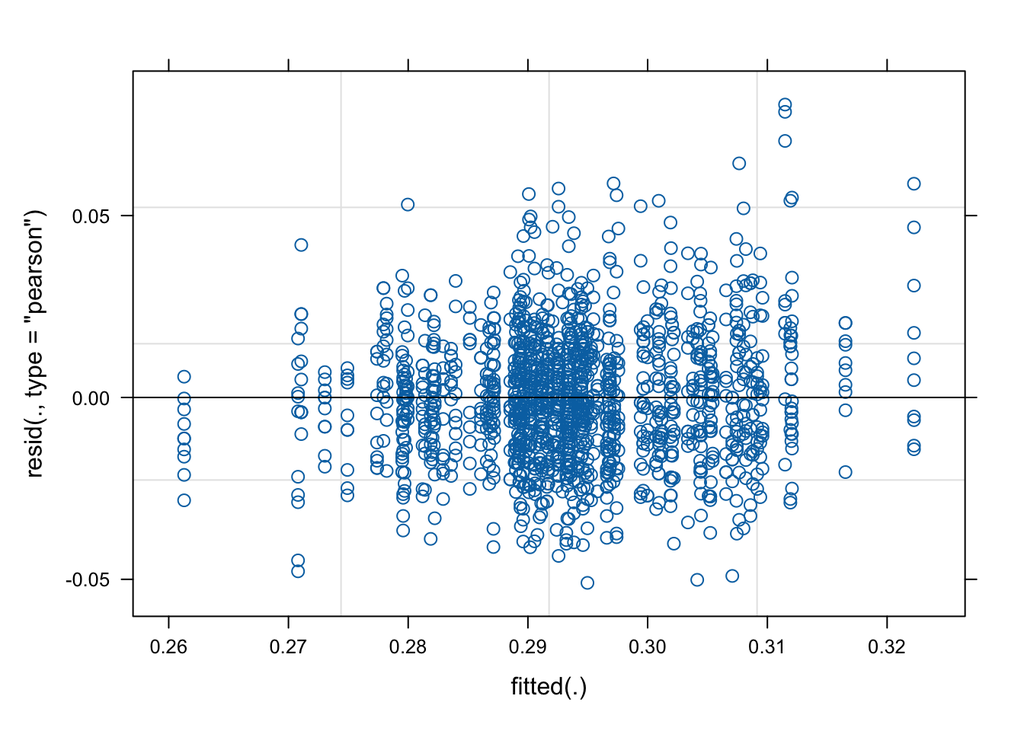

```r
plot(emb_size_lm1)
```

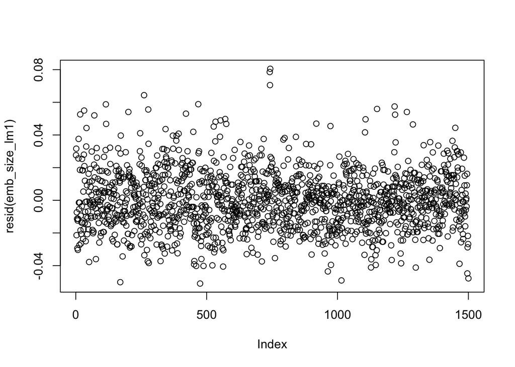

```r
plot(resid(emb_size_lm1))
```

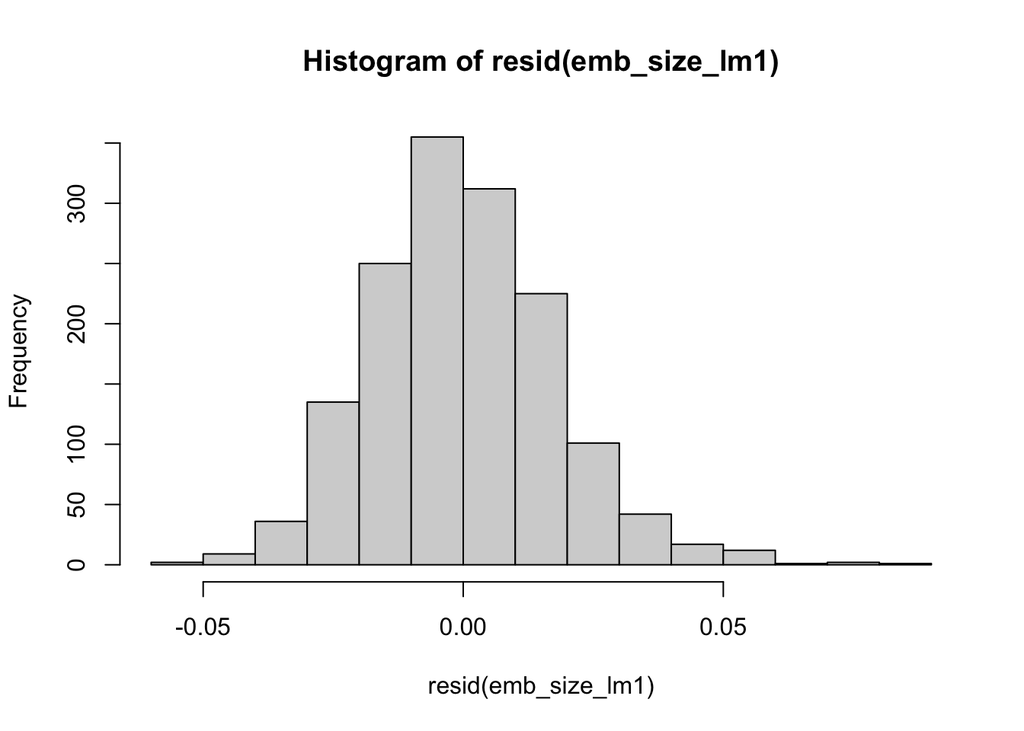

```r
hist(resid(emb_size_lm1))
```

Q-Q plot of model residuals

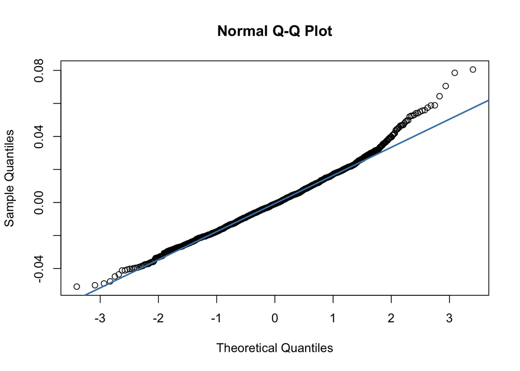

```r
qqnorm(resid(emb_size_lm1))
qqline(resid(emb_size_lm1), col = "steelblue", lwd = 2)
```

### Hatchling number

Import data

```r
hatch_number <- read.csv("/Users/keiramonuki/Documents/Sanford\ Lab/snail_tank_experiment/hatch_num_new.csv")

head(hatch_number)
```

```
##        ID Pop Treatment Breeding_pair Capsule_ID Num_hatch Avg_Size
## 1 YB_H9_1  YB         H             9          1        36     19.4
## 2 YB_H9_2  YB         H             9          2        28     19.4
## 3 YB_H9_4  YB         H             9          4        32     19.4
## 4 YB_H2_1  YB         H             2          1        28     21.7
## 5 YB_H2_4  YB         H             2          4        33     21.7
## 6 YB_H2_2  YB         H             2          2        32     21.7
```

Remove data from cold treatment and from RP population (not enough data for either)

```r
hatch_number %>%
  filter(Treatment == "H") %>%
  filter(Pop != "RP") %>%
  filter(Breeding_pair != "23")-> hatch_number


head(hatch_number)
```

```
##        ID Pop Treatment Breeding_pair Capsule_ID Num_hatch Avg_Size
## 1 YB_H9_1  YB         H             9          1        36     19.4
## 2 YB_H9_2  YB         H             9          2        28     19.4
## 3 YB_H9_4  YB         H             9          4        32     19.4
## 4 YB_H2_1  YB         H             2          1        28     21.7
## 5 YB_H2_4  YB         H             2          4        33     21.7
## 6 YB_H2_2  YB         H             2          2        32     21.7
```

Look at raw data distribution including mean and standard deviation

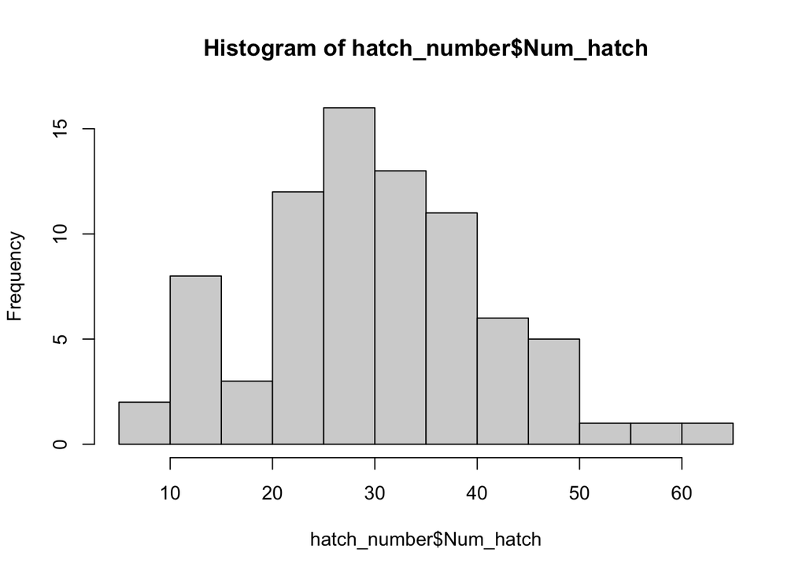

```r
hist(hatch_number$Num_hatch)
```

```r
mean(hatch_number$Num_hatch)
```

```
## [1] 30.49367
```

```r
sd(hatch_number$Num_hatch)
```

```
## [1] 11.18363
```

Run a GLMM with a negative binomial distribution and log link function, and calculate AIC values.

```r
hatch_num_nb <-
  glm.nb(Num_hatch ~ Avg_Size + Pop + (1 | Breeding_pair), data = hatch_number)

summary(hatch_num_nb)
```

```
##
## Call:
## glm.nb(formula = Num_hatch ~ Avg_Size + Pop + (1 | Breeding_pair),
##     data = hatch_number, init.theta = 13.48924838, link = log)
##
## Coefficients: (1 not defined because of singularities)
##                       Estimate Std. Error z value Pr(>|z|)
## (Intercept)            1.17729    0.50478   2.332   0.0197 *
## Avg_Size               0.10127    0.02257   4.487 7.21e-06 ***
## PopMB                  0.04526    0.09351   0.484   0.6284
## PopYB                  0.14641    0.10596   1.382   0.1670
## 1 | Breeding_pairTRUE       NA         NA      NA       NA
## ---
## Signif. codes:  0 '***' 0.001 '**' 0.01 '*' 0.05 '.' 0.1 ' ' 1
##
## (Dispersion parameter for Negative Binomial(13.4892) family taken to be 1)
##
##     Null deviance: 105.985  on 78  degrees of freedom
## Residual deviance:  81.985  on 75  degrees of freedom
## AIC: 593.12
##
## Number of Fisher Scoring iterations: 1
##
##
##               Theta:  13.49
##           Std. Err.:  3.20
##
##  2 x log-likelihood:  -583.122
```

```r
anova(hatch_num_nb)
```

```
## Analysis of Deviance Table
##
## Model: Negative Binomial(13.4892), link: log
##
## Response: Num_hatch
##
## Terms added sequentially (first to last)
##
##
##                   Df Deviance Resid. Df Resid. Dev  Pr(>Chi)
## NULL                                 78    105.985
## Avg_Size           1  22.1044        77     83.880 2.582e-06 ***
## Pop                2   1.8955        75     81.985    0.3876
## 1 | Breeding_pair  0   0.0000        75     81.985
## ---
## Signif. codes:  0 '***' 0.001 '**' 0.01 '*' 0.05 '.' 0.1 ' ' 1
```

```r
Anova(hatch_num_nb)
```

```
## Analysis of Deviance Table (Type II tests)
##
## Response: Num_hatch
##                   LR Chisq Df Pr(>Chisq)
## Avg_Size           19.8110  1  8.549e-06 ***
## Pop                 1.8955  2     0.3876
## 1 | Breeding_pair           0
## ---
## Signif. codes:  0 '***' 0.001 '**' 0.01 '*' 0.05 '.' 0.1 ' ' 1
```

```r
AIC(hatch_num_nb)
```

```
## [1] 593.1221
```

```r
AICc(hatch_num_nb)
```

```
## [1] 593.944
```

Back-transform model estimates to plot on top of the raw data scatter

```r
emmeans(hatch_num_nb, "Pop", type  = "response", data = hatch_number)
```

```
##  Pop response   SE  df asymp.LCL asymp.UCL
##  DB      28.0 1.99 Inf      24.3      32.2
##  MB      29.3 2.01 Inf      25.6      33.5
##  YB      32.4 2.24 Inf      28.3      37.1
##
## Confidence level used: 0.95
## Intervals are back-transformed from the log scale
```

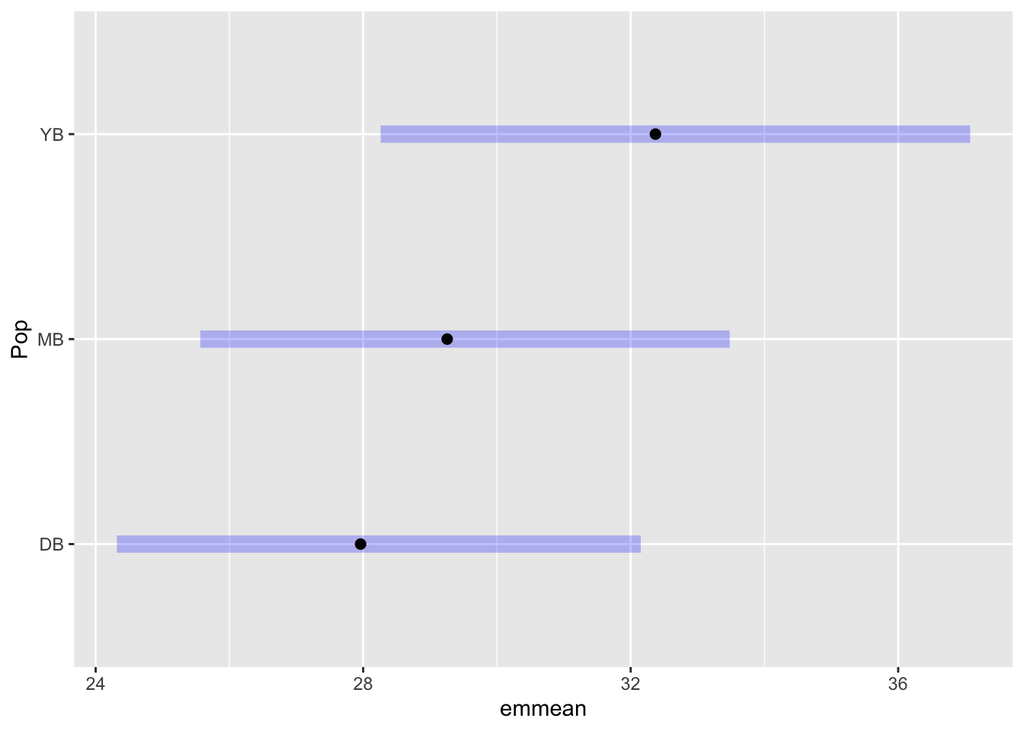

```r
estimates <- emmeans(hatch_num_nb, "Pop", type  = "response", data = hatch_number)

plot(estimates)
```

```r
estimates
```

```
##  Pop response   SE  df asymp.LCL asymp.UCL
##  DB      28.0 1.99 Inf      24.3      32.2
##  MB      29.3 2.01 Inf      25.6      33.5
##  YB      32.4 2.24 Inf      28.3      37.1
##
## Confidence level used: 0.95
## Intervals are back-transformed from the log scale
```

Create data frame of the back-transformed model estimates

```r
est <- c(28.0, 29.3, 32.4)
err_high <- c(32.2, 33.5, 37.1)
err_low <- c(24.3, 25.6, 28.3)

hatch_num <- data.frame(Pop = site, Estimate = est, Error_high = err_high, Error_low = err_low)
hatch_num
```

```
##   Pop Estimate Error_high Error_low
## 1  DB     28.0       32.2      24.3
## 2  MB     29.3       33.5      25.6
## 3  YB     32.4       37.1      28.3
```

Plot hatchling number across populations

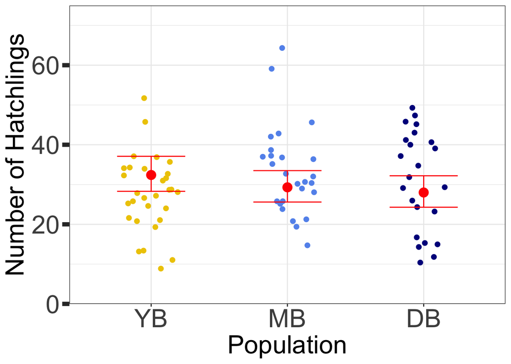

```r
ggplot(hatch_number, aes(x = Pop, y = Num_hatch, color = Pop)) +
  geom_jitter(aes(x = Pop, y = Num_hatch), position=position_jitter(w=0.2), size = 2) +
  scale_color_manual(values = c("gold2", "cornflowerblue","darkblue")) +
  geom_point(data = hatch_num, aes(x = Pop, y = Estimate), size = 4,  color = "red") +
  geom_errorbar(data = hatch_num, aes(x = Pop, y = Estimate, ymin = Error_low, ymax = Error_high), color = "red", width = 0.5) +
  theme_bw() +
  theme(legend.position = "none",
        axis.title = element_text(size=25),
        axis.text = element_text(size=25),
        axis.ticks.y = element_line(linewidth = 2),
        axis.ticks.length.y = unit(0.25, "cm")) +
  scale_y_continuous(name = "Number of Hatchlings", expand = c(0,0), limits = c(0,75)) +
  xlab("Population") -> hatch_num_plot

hatch_num_plot$data$Pop <- factor(hatch_num_plot$data$Pop, levels=neworder)

hatch_num_plot
```

Plot model residuals to assess model fit

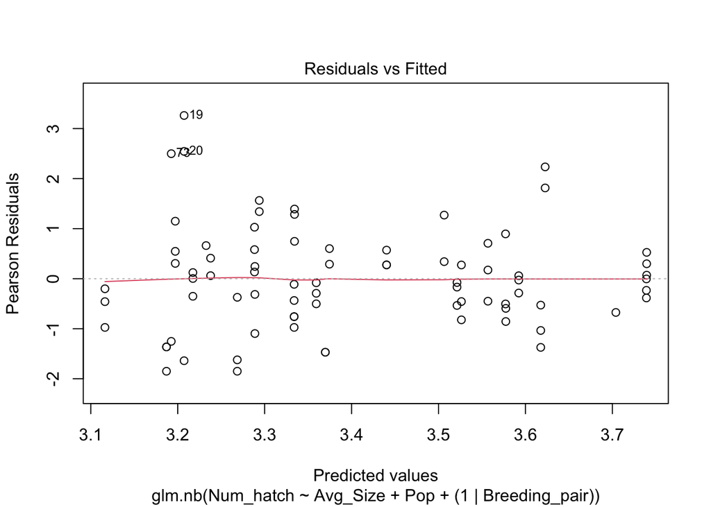

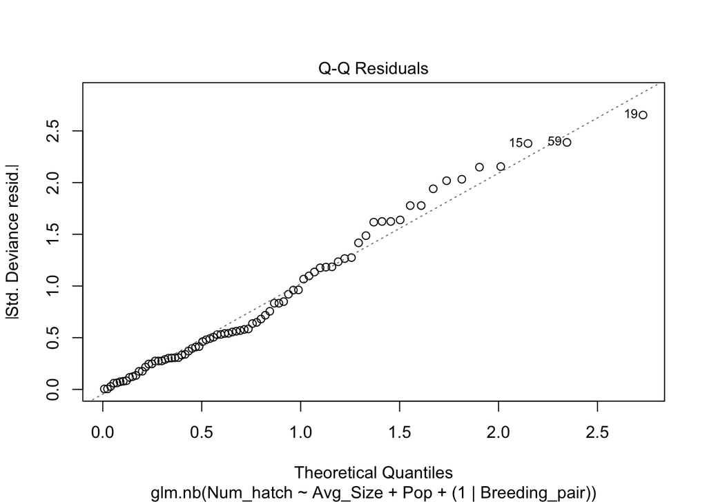

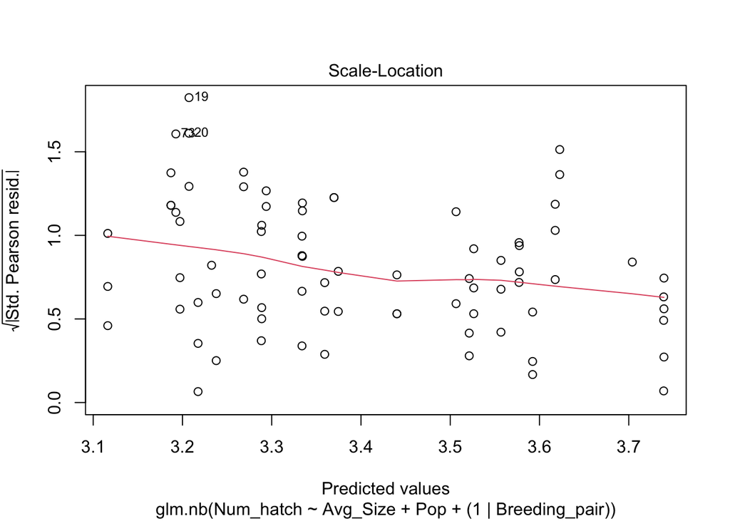

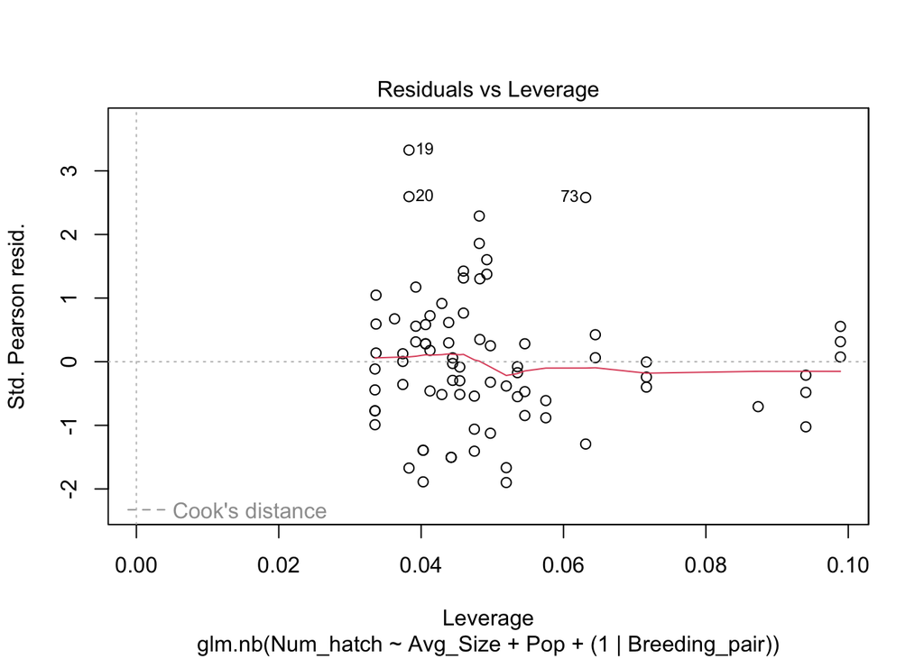

```r
plot(hatch_num_nb)
```

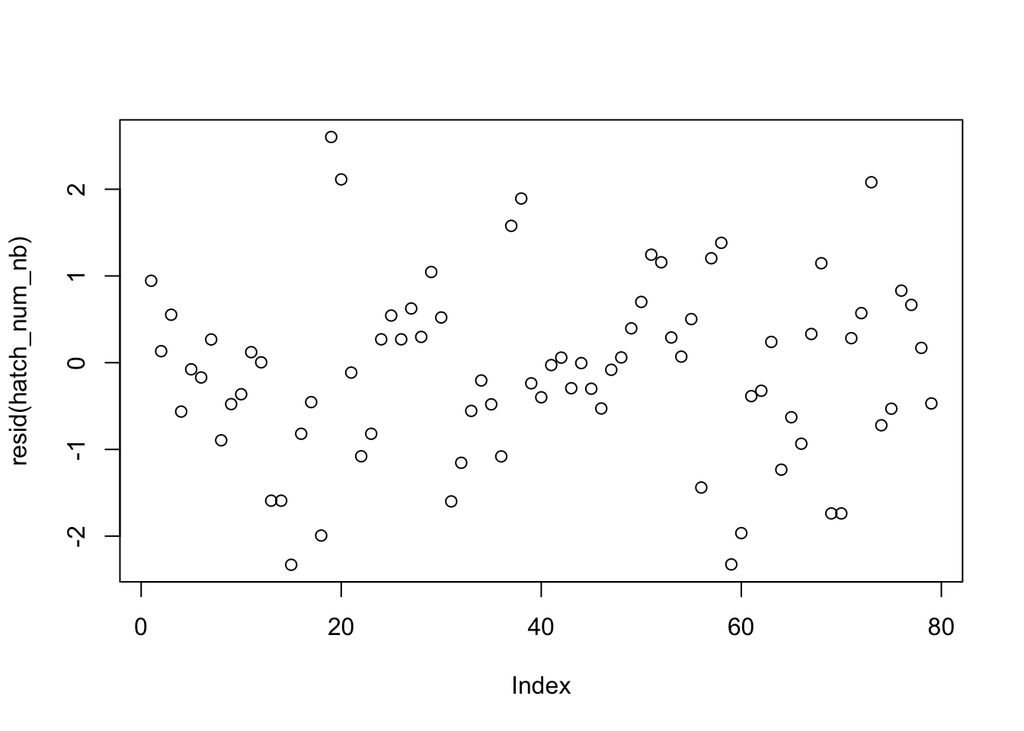

```r
plot(resid(hatch_num_nb))
```

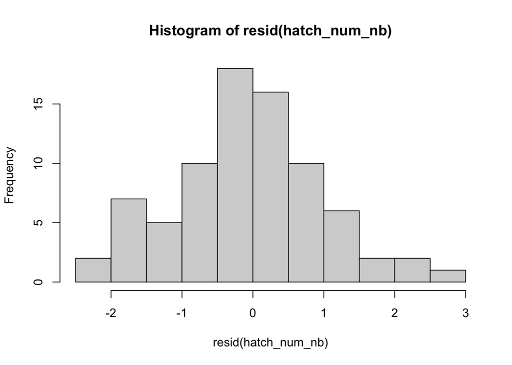

```r
hist(resid(hatch_num_nb))
```

Q-Q plot for model residuals

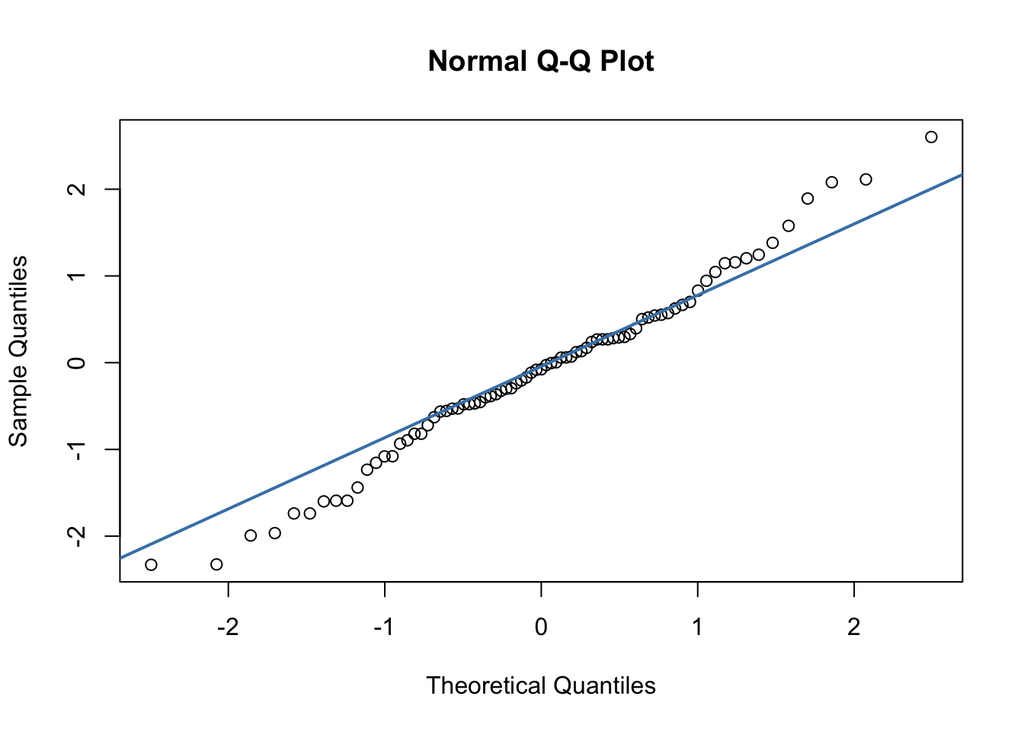

```r
qqnorm(resid(hatch_num_nb))
qqline(resid(hatch_num_nb), col = "steelblue", lwd = 2)
```

### Development Time

Import data

```r
dev_time <- read.csv("/Users/keiramonuki/Documents/Sanford\ Lab/snail_tank_experiment/dev_time_new.csv")

head(dev_time)
```

```
##       ID Pop Treatment Breeding_pair Hatch_start Hatch_end Time Avg_Size
## 1 DB_H23  DB         H            23      4/1/24    5/9/24   38    30.10
## 2  MB_H7  MB         H             7     3/12/24    5/6/24   55    23.65
## 3 MB_H20  MB         H            20     3/28/24    5/6/24   39    18.70
## 4  YB_H2  YB         H             2      4/4/24   5/14/24   40    21.70
## 5  DB_H4  DB         H             4     4/22/24   5/28/24   36    21.30
## 6 YB_H13  YB         H            13     4/22/24    6/3/24   42    18.40
```

Remove data from cold treatment and from RP population (not enough data for either)

```r
dev_time %>%
  filter(Treatment == "H") %>%
  filter(Pop != "RP") %>%
  filter(ID != "DB_H23")-> dev_time

head(dev_time)
```

```
##       ID Pop Treatment Breeding_pair Hatch_start Hatch_end Time Avg_Size
## 1  MB_H7  MB         H             7     3/12/24    5/6/24   55    23.65
## 2 MB_H20  MB         H            20     3/28/24    5/6/24   39    18.70
## 3  YB_H2  YB         H             2      4/4/24   5/14/24   40    21.70
## 4  DB_H4  DB         H             4     4/22/24   5/28/24   36    21.30
## 5 YB_H13  YB         H            13     4/22/24    6/3/24   42    18.40
## 6  MB_H2  MB         H             2     4/22/24    6/3/24   42    23.70
```

Check distribution of the raw data, including mean and standard deviation

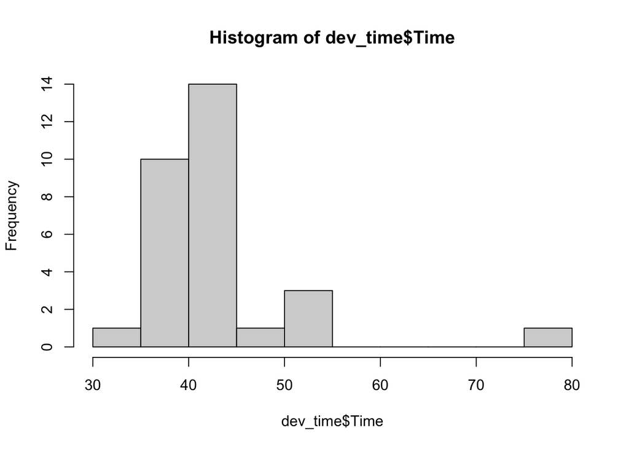

```r
hist(dev_time$Time)
```

```r
mean(dev_time$Time)
```

```
## [1] 42.5
```

```r
sd(dev_time$Time)
```

```
## [1] 7.868532
```

Run a GLMM with a negative binomial distribution and log link function, and calculate AIC values

```r
dev_time_nb <- glm.nb(Time ~ Avg_Size + Pop, data = dev_time)
summary(dev_time_nb)
```

```
##
## Call:
## glm.nb(formula = Time ~ Avg_Size + Pop, data = dev_time, init.theta = 834.1319716,
##     link = log)
##
## Coefficients:
##             Estimate Std. Error z value Pr(>|z|)
## (Intercept)  2.81069    0.38933   7.219 5.23e-13 ***
## Avg_Size     0.04029    0.01727   2.333   0.0197 *
## PopMB        0.11273    0.06984   1.614   0.1065
## PopYB        0.10519    0.08435   1.247   0.2124
## ---
## Signif. codes:  0 '***' 0.001 '**' 0.01 '*' 0.05 '.' 0.1 ' ' 1
##
## (Dispersion parameter for Negative Binomial(834.132) family taken to be 1)
##
##     Null deviance: 35.084  on 29  degrees of freedom
## Residual deviance: 26.020  on 26  degrees of freedom
## AIC: 204.86
##
## Number of Fisher Scoring iterations: 1
##
##
##               Theta:  834
##           Std. Err.:  3832
## Warning while fitting theta: alternation limit reached
##
##  2 x log-likelihood:  -194.859
```

```r
anova(dev_time_nb)
```

```
## Analysis of Deviance Table
##
## Model: Negative Binomial(834.132), link: log
##
## Response: Time
##
## Terms added sequentially (first to last)
##
##
##          Df Deviance Resid. Df Resid. Dev Pr(>Chi)
## NULL                        29     35.084
## Avg_Size  1   6.0511        28     29.033   0.0139 *
## Pop       2   3.0127        26     26.020   0.2217
## ---
## Signif. codes:  0 '***' 0.001 '**' 0.01 '*' 0.05 '.' 0.1 ' ' 1
```

```r
Anova(dev_time_nb)
```

```
## Analysis of Deviance Table (Type II tests)
##
## Response: Time
##          LR Chisq Df Pr(>Chisq)
## Avg_Size   5.4523  1    0.01954 *
## Pop        3.0127  2    0.22172
## ---
## Signif. codes:  0 '***' 0.001 '**' 0.01 '*' 0.05 '.' 0.1 ' ' 1
```

```r
AIC(dev_time_nb)
```

```
## [1] 204.8591
```

```r
AICc(dev_time_nb)
```

```
## [1] 207.3591
```

Plot model residuals to assess model fit

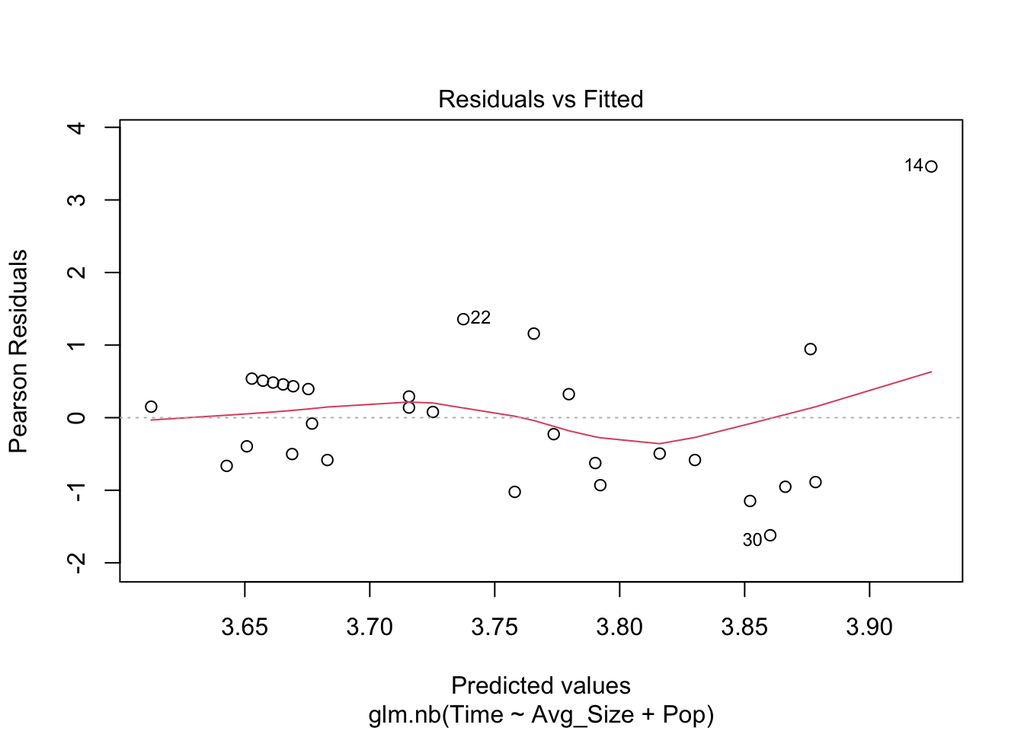

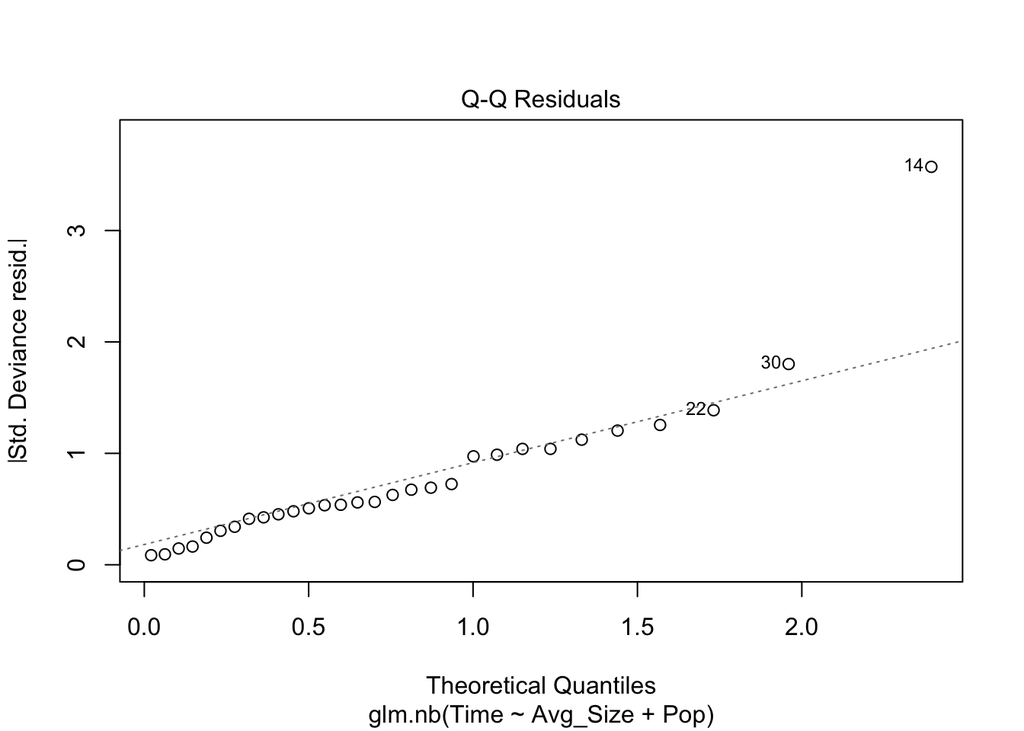

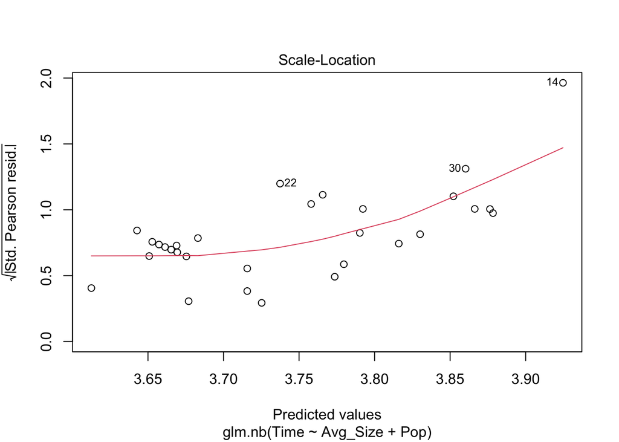

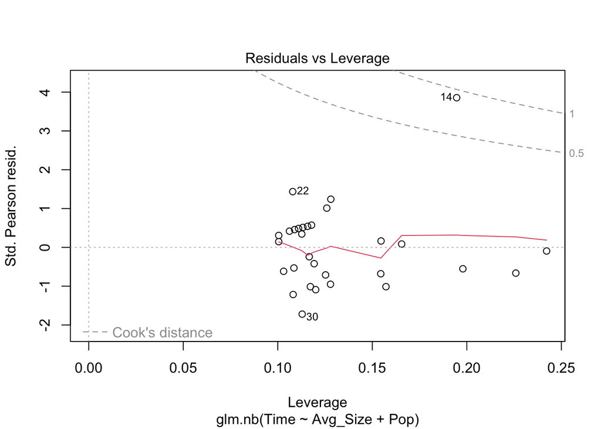

```r
plot(dev_time_nb)
```

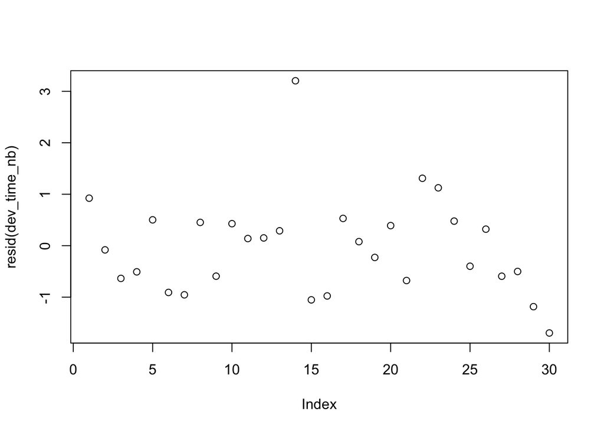

```r
plot(resid(dev_time_nb))
```

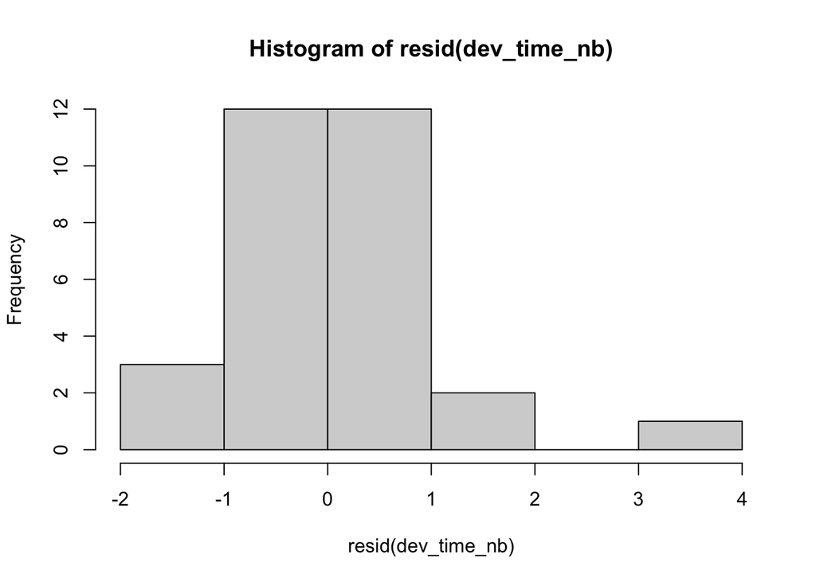

```r
hist(resid(dev_time_nb))
```

Q-Q plot for model residuals

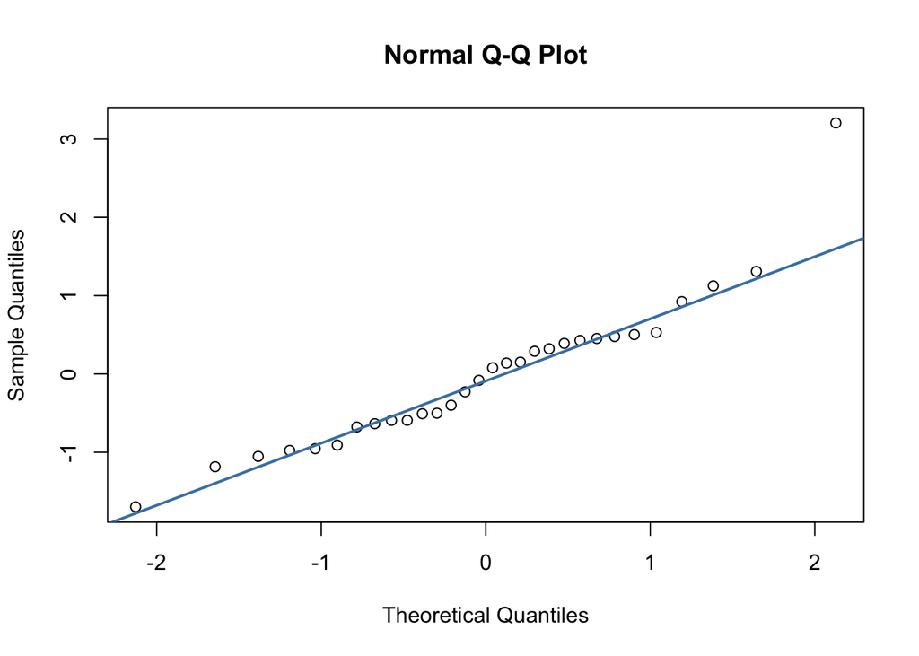

```r
qqnorm(resid(dev_time_nb))
qqline(resid(dev_time_nb), col = "steelblue", lwd = 2)
```

Back-transform model estimates to plot on top of the raw data scatter

```r
emmeans(dev_time_nb, "Pop", type  = "response", data = dev_time)
```

```
##  Pop response   SE  df asymp.LCL asymp.UCL
##  DB      39.4 2.10 Inf      35.5      43.7
##  MB      44.1 2.25 Inf      39.9      48.7
##  YB      43.7 2.54 Inf      39.0      49.0
##
## Confidence level used: 0.95
## Intervals are back-transformed from the log scale
```